# Effect of Physical, Social, and Economic Factors on Obesity

### 2.0.1 Summary of dataset tidy process

In order to start to construct my tidy dataset, I first downloaded the pertinent datasets from the NHANES database. These were converted outside of R from XPT files to CSV files using SAS Universal Viewer. The CSV files were read into R using the read.csv function. Once the CSV files were loaded, the variables of choice from each dataset were selected, including the subject ID “SEQN” which served as a link between the datasets. The datasets were merged in a stepwise fashion to create a single large dataset. In each step, 2 datasets were merged and then the observations without complete data were removed from the merged dataset using the complete.cases function. This was performed in a stepwise fashion to prevent R from crashing through the merging process.

Once the dataset was complete, non-informative data was filtered out so that all observations were both complete and contained useful data. Data which was filtered out included place-holder data indicating “Refused to Answer” or “Do Not Know.” The variable names for the variables which would remain through to analysis were renamed to a more informative name. For example, “WHD020” was changed to “weight.” This completed the NHANES_raw dataset.

New variables created to convert a numeric outcome into a binary outcome.

- Calculated BMI outcome: The BMI of participants was collected in the NHANES project. The variable containing the numeric values was converted into a binary variable (BMI_bin) using the BMI classification structure from the World Health Organization (http://apps.who.int/bmi/index.jsp?introPage=intro_3.html). BMI values below 25.0 were classified as Normal/under weight. BMI values at or above 25.0 were classified as Overweight/Obese. BMI_f contains the text version of the classifications.

New variables were calculated to create informative factors. The calculated variables are as follows:

- Taste Tests: For the “taste” variable, I used two tests used in the NHANES database. The participant was given 20 mL of a 1 mM solution of quinine (which has a bitter taste) and 1 mM NaCl (which has a salty taste). The participant was to swish the sample around their whole mouth and then identify what taste it elicited, out of 4 multiple choice responses. For the calculations, each correct answer was coded with a 1, each incorrect answer was coded with a 0. The numerical variable “taste” was created by summing the two coded taste test results. The factored variable “taste_f” was also created which leveled the test results. A sum of both tests resulting in a 2 (both tests correctly identified) was coded as “Normal.” A sum of 1 (only one test correctly identified) was coded as “Borderline” and a sum of 0 (both tests incorrect) was coded as “Impaired.” The concept for using this test series is that a normal or impaired sense of taste may affect the desire a person has to consume food.
- Smell Tests: For the “smell” variable, I used a series of 8 scent identification tests used in the NHANES project. The participant was asked to smell a scratch and sniff card and identify the specific scent, from a choice of 4 multiple choice responses. The scents were: chocolate, strawberry, soap, smoke, leather, grape, onion, and natural gas. Each correct answer was coded with a 1, each incorrect was coded as a 0. The numerical variable “smell” was created by summing the results of all 8 tests. A factored variable “smell_f” was created with the following levels: 0-2 correct = Severe impairment, 3-4 = Moderate impairment, 5-6 = Mild impairment, and 7-8, Normal, or no impairment. The concept for using this test series is that a normal or impaired sense of smell significantly affects the sense of taste and, therefore, may affect the desire a person has to consume food.
- Food Insecurity: Participants in the NHANES project were given 3 statements regarding food insecurity. “I/We worried whether my/our food would run out before I/we got money to buy more.” “The food the I/we bought just didn’t last, and I/we didn’t have money to get more.” “I/we couldn’t afford to eat balanced meals.” The possible response options were given and each was coded by NHANES: 1 = “often true” 2 = “Sometimes true” and 3 = “Never true” The numerical variable “food” was created by summing the results of all 3 questions. A factored variable “food_f” was created with the following levels, in terms of the level of food insecurity the participant experiences: 3-4 = “severe” 5-7 = “moderate” and 8-9 = “mild/none.” The concept behind using this variable is that when people suffer from food insecurity, it might affect the amount or quality of food to which they have access, which may affect subsequent weight.

# 3 Task 3: Listing of My Tibble

```r
tidy1000  %>% tbl_df
```

```
# A tibble: 1,000 x 19
    SEQN weight   bmi BMI_bin                 BMI_f   age  sex_f
 * <chr>  <int> <dbl>   <dbl>                <fctr> <int> <fctr>
 1 74548    130  21.6       0 a. Normal/Underweight    63      2
 2 79469    123  19.7       0 a. Normal/Underweight    80      1
 3 73807    154  27.8       1   b. Overweight/Obese    50      2
 4 83556    145  26.8       1   b. Overweight/Obese    55      2
 5 82005    169  27.9       1   b. Overweight/Obese    68      1
 6 81624    127  23.2       0 a. Normal/Underweight    62      2
 7 73811    208  31.8       1   b. Overweight/Obese    64      1
 8 76827    170  28.2       1   b. Overweight/Obese    72      2
 9 77411    127  22.0       0 a. Normal/Underweight    44      2
10 75058    165  29.4       1   b. Overweight/Obese    66      2
# ... with 990 more rows, and 12 more variables: sex_f_name <fctr>,
#   health_f <fctr>, oral_f <fctr>, smoke <dbl>, sleep <int>, rest <int>,
#   taste <dbl>, taste_f <fctr>, smell <dbl>, smell_f <fctr>, food <int>,
#   food_f <fctr>
```

```r
str(tidy1000)
```

```
'data.frame':   1000 obs. of  19 variables:
 $ SEQN      : chr  "74548" "79469" "73807" "83556" ...
 $ weight    : int  130 123 154 145 169 127 208 170 127 165 ...
 $ bmi       : num  21.6 19.7 27.8 26.8 27.9 23.2 31.8 28.2 22 29.4 ...
 $ BMI_bin   : num  0 0 1 1 1 0 1 1 0 1 ...
 $ BMI_f     : Factor w/ 2 levels "a. Normal/Underweight",..: 1 1 2 2 2 1 2 2 1 2 ...
 $ age       : int  63 80 50 55 68 62 64 72 44 66 ...
 $ sex_f     : Factor w/ 2 levels "1","2": 2 1 2 2 1 2 1 2 2 2 ...
 $ sex_f_name: Factor w/ 2 levels "Male","Female": 2 1 2 2 1 2 1 2 2 2 ...
 $ health_f  : Factor w/ 5 levels "1","2","3","4",..: 4 2 3 3 3 3 2 3 3 3 ...
 $ oral_f    : Factor w/ 6 levels "1","2","3","4",..: 3 1 1 2 6 2 3 6 1 1 ...
 $ smoke     : num  0.011 0.011 0.011 0 0.016 0.023 0 0.208 286 0.015 ...
 $ sleep     : int  7 8 8 9 8 6 8 10 6 8 ...
 $ rest      : int  240 600 720 540 300 360 600 240 240 240 ...
 $ taste     : num  0 2 2 2 2 2 1 0 2 2 ...
 $ taste_f   : Factor w/ 3 levels "c. Impaired",..: 1 3 3 3 3 3 2 1 3 3 ...
 $ smell     : num  6 6 8 8 6 6 8 4 6 8 ...
 $ smell_f   : Factor w/ 4 levels "d. Severe","c. Moderate",..: 3 3 4 4 3 3 4 2 3 4 ...
 $ food      : int  8 9 9 9 9 9 9 6 4 9 ...
 $ food_f    : Factor w/ 3 levels "c. Severe","b. Moderate",..: 3 3 3 3 3 3 3 2 1 3 ...
```

```r
summary(tidy1000)
```

```
     SEQN               weight         bmi           BMI_bin
 Length:1000        Min.   : 81   Min.   :14.20   Min.   :0.000
 Class :character   1st Qu.:150   1st Qu.:24.80   1st Qu.:0.000
 Mode  :character   Median :174   Median :28.20   Median :1.000
                    Mean   :180   Mean   :29.51   Mean   :0.741
                    3rd Qu.:204   3rd Qu.:32.52   3rd Qu.:1.000
                    Max.   :400   Max.   :77.50   Max.   :1.000
                   BMI_f          age        sex_f    sex_f_name  health_f
 a. Normal/Underweight:259   Min.   :40.00   1:486   Male  :486   1: 63
 b. Overweight/Obese  :741   1st Qu.:50.00   2:514   Female:514   2:243
                             Median :60.00                        3:421
                             Mean   :59.56                        4:236
                             3rd Qu.:68.00                        5: 37
                             Max.   :80.00
 oral_f      smoke              sleep             rest
 1:456   Min.   :   0.000   Min.   : 0.000   Min.   :   1.0
 2:160   1st Qu.:   0.011   1st Qu.: 6.000   1st Qu.: 240.0
 3: 99   Median :   0.024   Median : 7.000   Median : 480.0
 4: 74   Mean   :  59.456   Mean   : 6.866   Mean   : 420.5
 5: 56   3rd Qu.:   0.604   3rd Qu.: 8.000   3rd Qu.: 540.0
 6:155   Max.   :1030.000   Max.   :12.000   Max.   :1080.0
     taste                taste_f        smell              smell_f
 Min.   :0.000   c. Impaired  :122   Min.   :0.000   d. Severe  : 46
 1st Qu.:1.000   b. Borderline:190   1st Qu.:6.000   c. Moderate: 77
 Median :2.000   a. Normal    :688   Median :7.000   b. Mild    :288
 Mean   :1.566                       Mean   :6.399   a. Normal  :589
 3rd Qu.:2.000                       3rd Qu.:8.000
 Max.   :2.000                       Max.   :8.000
      food                food_f
 Min.   :3.000   c. Severe   : 47
 1st Qu.:9.000   b. Moderate :159
 Median :9.000   a. Mild/none:794
 Mean   :8.239
 3rd Qu.:9.000
 Max.   :9.000
```

```r
write.csv(tidy1000,"PlanchonPope-tidy.csv", row.names=FALSE,na="NA")
```

# 4 Task 4: Code Book

Here, I suggest you create a table like this, but if you’ve got a more effective way to accomplish the goal, please use it. A sample is shown below.

[output not shown]

# 5 Task 5: My Subjects

# 6 Task 6: My Variables

- SEQN: Participant identification number. This number is unique to each participant and was used to link the data across datasets within the NHANES database.
- weight: The self-reported weight of the participant, in pounds. Collected from males and females ages 16 to 150 years.
- bmi: Body Mass Index (BMI) of participants. Numerical value, calculated during the visit. Results in kg/m^2. Collected from males and females ages 2 to 150 years.
- bmi_bin: A binary variable for BMI created from the variable bmi. Participants with a BMI below 25.0 were coded with a “0”. Participants with a BMI at or above 25.0 were coded with a “1”.
- bmi_f: A factored variable with 2 levels, recoded from the variable bim_bin. Observations of “0” were coded as “Normal/Underweight” and observations of “1” were coded as “Overweight/Obese.”
- age: Participant age, in years, at the time of screening. Collected from males and females ages 0 to 150 years.
- sex_f: Participant’s sex. Males were coded as “1” and Females were coded as “2.” Collected from males and females ages 0 to 150 years.
- sex_f_name: Participant’s sex. Males were coded as “1” and Females were coded as “2.” Collected from males and females ages 0 to 150 years. This variables was created by replacing the numerical “1” and “2” with “Male” and “Female” respectively.
- health: A factored variable with 5 levels reflecting the answer to the question: “Would you say your health in general is…?” Response options included: 1=Excellent, 2=Very Good, 3=Good, 4=Fair, and 5=Poor. Collected from males and females ages 12 to 150 years.
- oral_f: A factored variable reflecting the answer to the question “About how long has it been since you have seen a dentist?” The concept behind inclusion of this variable is that dental care is usually the the least consistently utilized form of health care. The frequency of dental care should be reflective of the level of care an individual pays to their overall health, with more recent visits likely to reflect a higher attention to general health care. Response options included: 1= 6m or less, 2= More than 6m, but not more than 1y, 3=More than 1y but not more than 2y, 4=More than 2y but not more than 3y, 5=More than 3y but not more than 5y, 6=More than 5y ago. Collected from males and females ages 1 to 150 years.
- smoke: A quantitative laboratory measure of serum cotinine levels, in ng/mL. Cotinine levels are a measure of recent cigarette exposure, whether it is first-hand or second-hand smoke. Collected from males and females ages 3 to 150 years.
- sleep: A quantitative variable reflecting the answer to the question: “How much sleep do you usually get at night on weekdays or workdays?” Response options were the number of hours, up to a ceiling of 12 hours. Respondents sleeping at or more than 12 hours a night were grouped together at 12 hours. Collected from males and females ages 16 to 150 years.
- rest: A quantitative variable reflecting the answer to the question: “How much time do you usually spend sitting on a typical day?” Response options were the number of minutes. Collected from males and females ages 12 to 150 years.
- taste: For the “taste” variable, I used two tests used in the NHANES database. The participant was given 20 mL of a 1 mM solution of quinine (which has a bitter taste) and 1 mM NaCl (which has a salty taste). The participant was to swish the sample around their whole mouth and then identify what taste it elicited, out of 4 multiple choice responses. For the calculations, each correct answer was coded with a 1, each incorrect answer was coded with a 0. The numerical variable “taste” was created by summing the two coded taste test results. The concept for using this test series is that a normal or impaired sense of taste may affect the desire a person has to consume food. Collected from males and females ages 40 to 150 years.
- taste_f: The factored variable “taste_f” was created from the variable “taste” which leveled the results found in the variable taste. A sum of both tests resulting in a 2 (both tests correctly identified) was coded as “Normal.” A sum of 1 (only one test correctly identified) was coded as “Borderline” and a sum of 0 (both tests incorrect) was coded as “Impaired.” The concept for using this test series is that a normal or impaired sense of taste may affect the desire a person has to consume food.
- smell: For the “smell” variable, I used a series of 8 scent identification tests used in the NHANES project. The participant was asked to smell a scratch and sniff card and identify the specific scent, from a choice of 4 multiple choice responses. The scents were: chocolate, strawberry, soap, smoke, leather, grape, onion, and natural gas. Each correct answer was coded with a 1, each incorrect was coded as a 0. The numerical variable “smell” was created by summing the results of all 8 tests. The concept for using this test series is that a normal or impaired sense of smell significantly affects the sense of taste and, therefore, may affect the desire a person has to consume food. Collected from males and females ages 40 to 150 years.
- smell_f: A factored variable created from the variable “smell” with the following levels: 0-2 correct = Severe impairment, 3-4 = Moderate impairment, 5-6 = Mild impairment, and 7-8, Normal, or no impairment. The concept for using this test series is that a normal or impaired sense of smell significantly affects the sense of taste and, therefore, may affect the desire a person has to consume food.
- food: Participants in the NHANES project were given 3 statements regarding food insecurity. “I/We worried whether my/our food would run out before I/we got money to buy more.” “The food the I/we bought just didn’t last, and I/we didn’t have money to get more.” “I/we couldn’t afford to eat balanced meals.” The possible response options were given and each was coded by NHANES: 1 = “often true” 2 = “Sometimes true” and 3 = “Never true” The numerical variable “food” was created by summing the results of all 3 questions. The concept behind using this variable is that when people suffer from food insecurity, it might affect the amount or quality of food to which they have access, which may affect subsequent weight. Collected from males and females ages 0 to 150 years.
- food_f: A factored variable “food_f” was created from the variable “food” with the following levels, in terms of the level of food insecurity the participant experiences: 3-4 = “severe” 5-7 = “moderate” and 8-9 = “mild/none.” The concept behind using this variable is that when people suffer from food insecurity, it might affect the amount or quality of food to which they have access, which may affect subsequent weight.

# 7 Task 7: My Planned Linear Regression Model

In this project, I will use the variable “weight” as my quantitative outcome. I will explore the relationship of a series of predictors with “weight” through the use of a linear model. I will include the potential confounders of age and sex in the model. The quantitative variables I will incorporate into the model are: smoke, sleep, and rest. The categorical variables I will incorporate are: health, oral, taste_f, smell_f, and food_f.

# 8 Task 8: My Planned Logistic Regression Model

Specify in a sentence or two exactly which (binary) variable will be your outcome, and then which four (or more) candidate predictors (one of which must be multi-categorical) will be considered for your logistic regression model.

In this project, I will use the binary variable BMI_bin as my outcome variable. BMI_bin was created by segmenting the variable BMI into 2 groups, according to the WHO’s categorical classifications of BMI. A BMI of under 25.0 was classified as “0” and these participants would be considered of normal weight or underweight. A BMI of 25.0 or over was classified as a “1” and these participants would be considered overweight or obese. I will explore the relationship of a series of predictors with “weight” through the use of a linearogisitc model. I will include the potential confounders of age and sex in the model. The quantitative variables I will incorporate into the model are: smoke, sleep, and rest. The categorical variables I will incorporate are: health, oral, taste_f, smell_f, and food_f.

# 9 Task 9: Affirmation

I affirm that my dataset meets all of the requirements specified in the project instructions.

- Shareable with the World: It is shareable with the world (that is how I obtained it initially).
- Size: I have 1000 observations, which is at the upper limit of the size requirements of between 100 and 1000 observations, inclusive.
- Outcomes: I have a quantitative outcome, “weight” and a binary categorical outcome, “BMI_bin.”
- Inputs: I have 10 regression inputs which will be used in the two models. Four (age, smoke, sleep, rest) are quantitative. Six are categorical (sex, health, oral, taste_f, smell_f, and food_f) and rage from 2-leveled to 6-leveled factors.
- Sample size/regression inputs calculation: I have 1000 observations. It should be feasible for me to study 4+(1000-100)/100 regression inputs. 4+(900/100) = 4+9 = 13. It is feasible for me to study up to 13 regression inputs with my sample size. I am studying 10, with the expectation that several will not meaningfully contribute to the model.
- I am certain that it is completely appropriate for these data to be shared with anyone, without any conditions. There are no concerns about privacy or security.

# 10 Task 10 Analysis: Linear Regression

For this linear regression analysis, I will build a linear model which will predict an individual’s weight from a series of predictor variables available in the NHANES database.

The first task in preparing for the linear regression analysis is to determine the potential impact each of my potential predictors may have on my outcome of choice. To this end, I will run a Spearman Rho-squared analysis of the predictor options. I specifically included a large number of predictor options beyond the required minimum of 4.

The potential confounders, sex and age, will be included in the model regardless of how they fare in the model development. I will also need to be wary of potential collinearity between some of my predictor variables. For example, the predictor “health” is a factored variable with 5 levels reflecting the answer to the question: “Would you say your health in general is…?” Response options included: 1=Excellent, 2=Very Good, 3=Good, 4=Fair, and 5=Poor. People who are extremely over or under weight may rank their health with a worse (higher) rating–and this may be a result of weight, not a cause of it.

## 10.1 Initial data review

### 10.1.1 Normality assessment of outcome variable

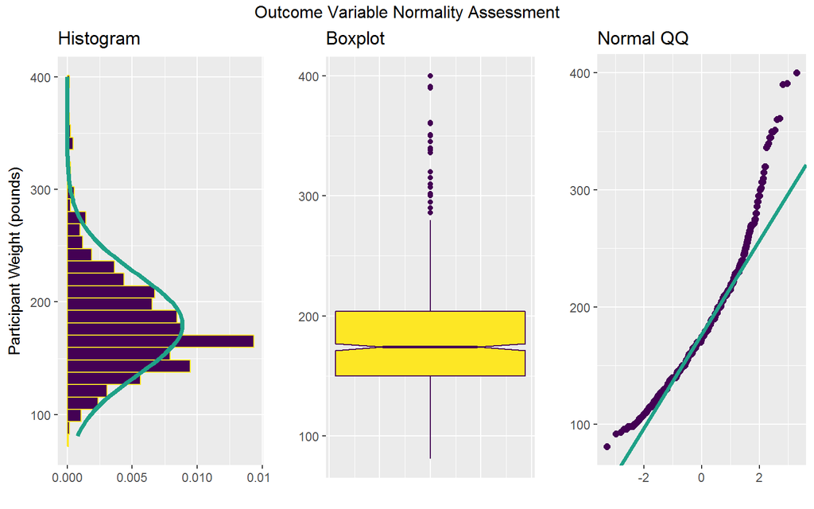

```r
eda.1sam(dataframe=tidy1000,
         variable=tidy1000$weight,
         x.title="Participant Weight (pounds)",
         ov.title="Outcome Variable Normality Assessment")
```

### 10.1.2 Transformation of outcome variable assessment

Since the outcome variable is not completely normal, I want to determine if a transformation might be helpful.

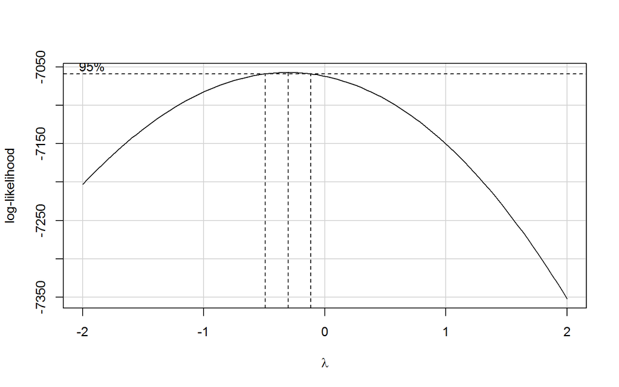

```r
boxCox(lm((weight) ~ age + sex_f + health_f + oral_f + smoke + sleep + rest + taste_f + smell_f + food_f, data=tidy1000))
```

I will consider transforming my outcome, weight, with a ln(x) transformation.

### 10.1.3 Normality assessment of transformed outcome variable

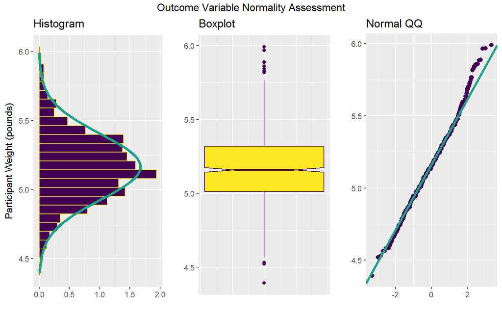

```r
eda.1sam(dataframe=tidy1000,
         variable=log(tidy1000$weight),
         x.title="Participant Weight (pounds)",
         ov.title="Outcome Variable Normality Assessment")
```

The log transformed outcome variable is MUCH more normally distributed. I will definitely use this in my model.

### 10.1.4 Spearman Rho-squared Plot

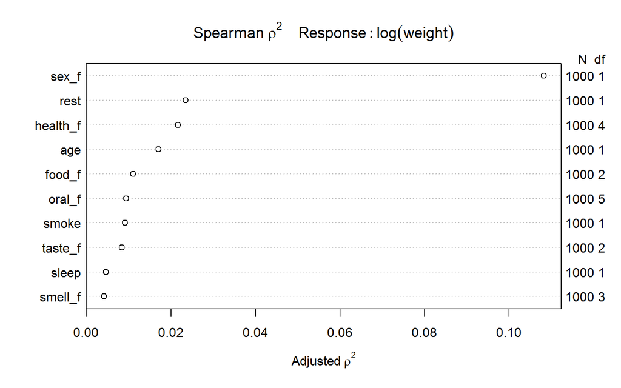

```r
plot(Hmisc::spearman2(log(weight) ~ age + sex_f + health_f + oral_f + smoke + sleep + rest + taste_f + smell_f + food_f, data=tidy1000))
```

### 10.1.5 Matrix Analysis

In order to investigate the relationship between the variables, a Matrix Analysis will be performed. This will identify collinearity between variables, if any exists, of which I must be mindful throughout the analyses.

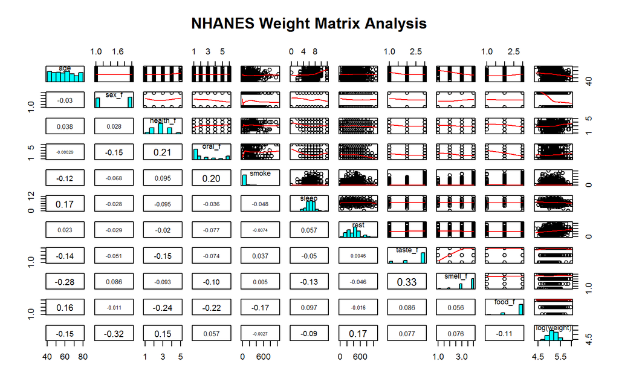

```r
pairs(~ age + sex_f + health_f + oral_f + smoke + sleep + rest + taste_f + smell_f + food_f + log(weight),
      data=tidy1000,
      main = "NHANES Weight Matrix Analysis",
      upper.panel = panel.smooth,
      diag.panel = panel.hist,
      lower.panel = panel.cor)
```

### 10.1.6 A look at the data distribution for the outcome variable ‘weight’ and the two expected confounders ‘sex_f’ and ‘age’

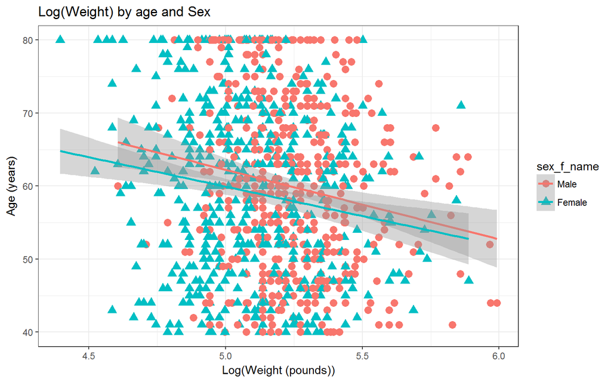

```r
confound2 <- ggplot(tidy1000, aes(x = log(weight), y = age, color = sex_f_name, shape = sex_f_name)) +
    geom_point(size = 3) +
  geom_smooth(method = "lm") +
    labs(title = "Log(Weight) by age and Sex",
         x = "Log(Weight (pounds))", y = "Age (years)") +
    theme_bw()

confound2
```

It does appear that both age and sex may affect the outcome variable. It appears that females weigh less than males (which was expected) and that there is a trend towards lower age as weight increases. As I initially thought that these may be confounders, I will require that they remain in the model.

## 10.2 Non-linearity analysis

### 10.2.1 Creating a modified kitchen sink models using lm

The variable, sex, is a binary factor, so no splines will be possible. Same with health_f which is a multi-leveled factor. I will first look at residual plots for small linear models predicting log(weight) to look for potential non-linearity. I will also add interaction terms between a few of these predictors as well (age, sex, rest, and health, assessed in pairs). The rest of the predictors may have influence, but the likelihood of much impact is low, so I will not worry about non-linear terms for these. The next 4 models will help determine whether non-linear terms will improve my final model.

#### 10.2.1.1 Non-linearity check for age

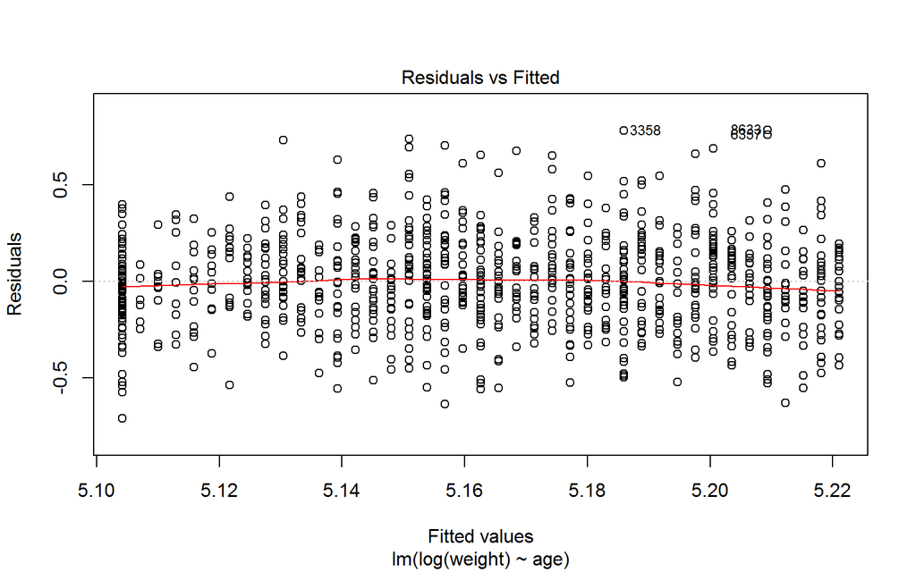

```r
plot(lm(log(weight) ~ age, data = tidy1000), which = 1)
```

The residual plot above shows that a non-linear term is not needed for the predictor age.

#### 10.2.1.2 Non-linearity check for rest

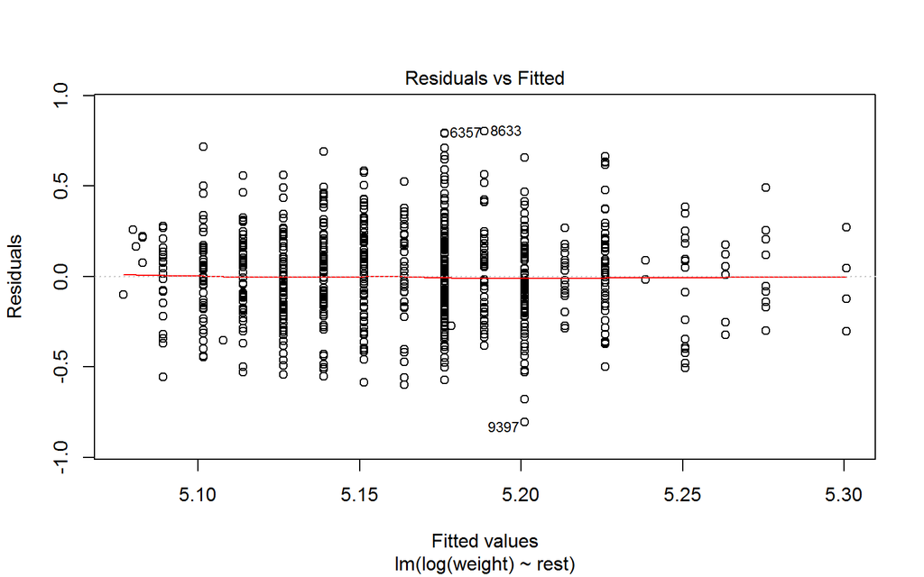

```r
plot(lm(log(weight) ~ rest, data = tidy1000), which = 1)
```

The residual plot above shows that a non-linear term is not needed for the predictor rest.

#### 10.2.1.3 Double-check for linearity assessment with the use of splines for age and rest

```r
mod1 <- lm(log(weight) ~ sex_f + rcs(age, 5) + health_f + rcs(rest, 5) + taste_f + smell_f  + sleep + oral_f + food_f + smoke, data = tidy1000)
summary(mod1)
```

```
Call:
lm(formula = log(weight) ~ sex_f + rcs(age, 5) + health_f + rcs(rest,
    5) + taste_f + smell_f + sleep + oral_f + food_f + smoke,
    data = tidy1000)

Residuals:
     Min       1Q   Median       3Q      Max
-0.65216 -0.14248 -0.00711  0.13036  0.72832

Coefficients:
                       Estimate Std. Error t value Pr(>|t|)
(Intercept)           4.823e+00  1.814e-01  26.593  < 2e-16 ***
sex_f2               -1.592e-01  1.386e-02 -11.483  < 2e-16 ***
rcs(age, 5)age        6.587e-03  3.656e-03   1.802  0.07192 .
rcs(age, 5)age'      -3.194e-02  1.562e-02  -2.044  0.04123 *
rcs(age, 5)age''      9.543e-02  4.975e-02   1.918  0.05539 .
rcs(age, 5)age'''    -1.591e-01  8.099e-02  -1.964  0.04979 *
health_f2             5.859e-02  3.024e-02   1.937  0.05299 .
health_f3             8.996e-02  2.913e-02   3.088  0.00207 **
health_f4             1.310e-01  3.117e-02   4.202 2.89e-05 ***
health_f5             1.920e-01  4.615e-02   4.160 3.47e-05 ***
rcs(rest, 5)rest      1.722e-04  1.687e-04   1.021  0.30753
rcs(rest, 5)rest'     3.091e-04  5.716e-04   0.541  0.58880
rcs(rest, 5)rest''   -9.496e-04  1.473e-03  -0.645  0.51929
taste_fb. Borderline  5.690e-02  2.707e-02   2.102  0.03579 *
taste_fa. Normal      4.814e-02  2.365e-02   2.035  0.04211 *
smell_fc. Moderate   -1.770e-02  4.067e-02  -0.435  0.66358
smell_fb. Mild       -1.312e-02  3.652e-02  -0.359  0.71951
smell_fa. Normal      2.027e-02  3.637e-02   0.557  0.57742
sleep                -7.627e-03  4.702e-03  -1.622  0.10511
oral_f2               1.810e-02  1.992e-02   0.908  0.36389
oral_f3               2.337e-02  2.385e-02   0.980  0.32755
oral_f4               4.575e-02  2.777e-02   1.647  0.09978 .
oral_f5              -4.666e-02  3.071e-02  -1.519  0.12897
oral_f6               9.882e-04  2.118e-02   0.047  0.96280
food_fb. Moderate     1.366e-02  3.594e-02   0.380  0.70386
food_fa. Mild/none   -2.908e-02  3.360e-02  -0.865  0.38699
smoke                -1.433e-04  4.989e-05  -2.873  0.00416 **
---
Signif. codes:  0 '***' 0.001 '**' 0.01 '*' 0.05 '.' 0.1 ' ' 1

Residual standard error: 0.2122 on 973 degrees of freedom
Multiple R-squared:  0.2265,    Adjusted R-squared:  0.2058
F-statistic: 10.96 on 26 and 973 DF,  p-value: < 2.2e-16
```

```r
mod2 <- lm(log(weight) ~ sex_f * age + health_f * rest + taste_f + smell_f  + sleep + oral_f + food_f + smoke, data = tidy1000)
summary(mod2)
```

```
Call:
lm(formula = log(weight) ~ sex_f * age + health_f * rest + taste_f +
    smell_f + sleep + oral_f + food_f + smoke, data = tidy1000)

Residuals:
     Min       1Q   Median       3Q      Max
-0.66159 -0.14065 -0.00881  0.12938  0.74135

Coefficients:
                       Estimate Std. Error t value Pr(>|t|)
(Intercept)           5.261e+00  9.950e-02  52.880  < 2e-16 ***
sex_f2               -1.418e-01  7.037e-02  -2.015  0.04415 *
age                  -2.408e-03  8.776e-04  -2.743  0.00619 **
health_f2             1.162e-02  7.052e-02   0.165  0.86920
health_f3             9.301e-02  6.799e-02   1.368  0.17163
health_f4             4.857e-02  7.089e-02   0.685  0.49338
health_f5             1.371e-01  1.232e-01   1.112  0.26629
rest                  1.256e-04  1.348e-04   0.931  0.35186
taste_fb. Borderline  6.227e-02  2.725e-02   2.285  0.02253 *
taste_fa. Normal      5.322e-02  2.385e-02   2.232  0.02586 *
smell_fc. Moderate   -1.532e-02  4.091e-02  -0.374  0.70817
smell_fb. Mild        6.993e-04  3.653e-02   0.019  0.98473
smell_fa. Normal      3.328e-02  3.638e-02   0.915  0.36051
sleep                -7.954e-03  4.697e-03  -1.693  0.09071 .
oral_f2               1.903e-02  2.007e-02   0.948  0.34321
oral_f3               2.722e-02  2.396e-02   1.136  0.25612
oral_f4               4.247e-02  2.773e-02   1.531  0.12602
oral_f5              -4.422e-02  3.081e-02  -1.435  0.15155
oral_f6               2.079e-03  2.127e-02   0.098  0.92216
food_fb. Moderate     2.266e-03  3.616e-02   0.063  0.95004
food_fa. Mild/none   -4.000e-02  3.377e-02  -1.185  0.23643
smoke                -1.265e-04  4.974e-05  -2.544  0.01112 *
sex_f2:age           -3.007e-04  1.160e-03  -0.259  0.79557
health_f2:rest        1.239e-04  1.512e-04   0.820  0.41255
health_f3:rest        3.135e-06  1.450e-04   0.022  0.98276
health_f4:rest        2.215e-04  1.529e-04   1.449  0.14774
health_f5:rest        1.387e-04  2.615e-04   0.530  0.59597
---
Signif. codes:  0 '***' 0.001 '**' 0.01 '*' 0.05 '.' 0.1 ' ' 1

Residual standard error: 0.2132 on 973 degrees of freedom
Multiple R-squared:  0.2192,    Adjusted R-squared:  0.1984
F-statistic: 10.51 on 26 and 973 DF,  p-value: < 2.2e-16
```

From this summary of mod2, the interaction terms between age and sex are not significant. The interaction between health and rest is also not significant. These interactions will be removed. The variables in this model which show significance are: age, sex, taste, and smoke. The variables which show no significance are: health, rest, smell, oral, and food. Next I will investigate another set of interactions.

```r
mod3 <- lm(log(weight) ~ sex_f * health_f + age *  rest + taste_f + smell_f  + sleep + oral_f + food_f + smoke, data = tidy1000)
summary(mod3)
```

```
Call:
lm(formula = log(weight) ~ sex_f * health_f + age * rest + taste_f +
    smell_f + sleep + oral_f + food_f + smoke, data = tidy1000)

Residuals:
     Min       1Q   Median       3Q      Max
-0.69124 -0.14122 -0.01357  0.12676  0.73788

Coefficients:
                       Estimate Std. Error t value Pr(>|t|)
(Intercept)           5.370e+00  1.134e-01  47.375  < 2e-16 ***
sex_f2               -2.686e-01  5.518e-02  -4.868 1.32e-06 ***
health_f2            -7.356e-03  4.627e-02  -0.159   0.8737
health_f3             2.748e-02  4.462e-02   0.616   0.5380
health_f4             7.178e-02  4.733e-02   1.517   0.1296
health_f5             1.247e-01  7.211e-02   1.729   0.0841 .
age                  -3.913e-03  1.440e-03  -2.717   0.0067 **
rest                  2.670e-05  1.824e-04   0.146   0.8837
taste_fb. Borderline  6.095e-02  2.727e-02   2.235   0.0256 *
taste_fa. Normal      5.068e-02  2.382e-02   2.128   0.0336 *
smell_fc. Moderate   -1.125e-02  4.103e-02  -0.274   0.7839
smell_fb. Mild        4.443e-03  3.667e-02   0.121   0.9036
smell_fa. Normal      3.699e-02  3.651e-02   1.013   0.3113
sleep                -7.802e-03  4.690e-03  -1.663   0.0965 .
oral_f2               1.817e-02  2.005e-02   0.906   0.3652
oral_f3               2.622e-02  2.400e-02   1.092   0.2749
oral_f4               4.342e-02  2.781e-02   1.561   0.1188
oral_f5              -4.341e-02  3.082e-02  -1.408   0.1594
oral_f6              -9.296e-04  2.132e-02  -0.044   0.9652
food_fb. Moderate     9.593e-03  3.602e-02   0.266   0.7900
food_fa. Mild/none   -3.368e-02  3.372e-02  -0.999   0.3180
smoke                -1.197e-04  4.967e-05  -2.410   0.0161 *
sex_f2:health_f2      1.225e-01  6.159e-02   1.990   0.0469 *
sex_f2:health_f3      1.132e-01  5.896e-02   1.921   0.0551 .
sex_f2:health_f4      1.141e-01  6.173e-02   1.849   0.0648 .
sex_f2:health_f5      1.230e-01  9.145e-02   1.345   0.1788
age:rest              3.097e-06  3.027e-06   1.023   0.3065
---
Signif. codes:  0 '***' 0.001 '**' 0.01 '*' 0.05 '.' 0.1 ' ' 1

Residual standard error: 0.2134 on 973 degrees of freedom
Multiple R-squared:  0.2183,    Adjusted R-squared:  0.1974
F-statistic: 10.45 on 26 and 973 DF,  p-value: < 2.2e-16
```

From this summary of mod3, the interaction terms between age and rest are not significant. This interaction will be removed. The interaction between sex and health is minimally significant. The variables in this model which show significance are: sex, age, smoke, taste, and a little for health and sleep. The variables which show no significance are: smell, oral, and food. Next I will investigate an interaction between sex and rest and also age and health.

```r
mod4 <- lm(log(weight) ~ age * health_f + sex_f * rest + taste_f + smell_f  + sleep + oral_f + food_f + smoke, data = tidy1000)
summary(mod4)
```

```
Call:
lm(formula = log(weight) ~ age * health_f + sex_f * rest + taste_f +
    smell_f + sleep + oral_f + food_f + smoke, data = tidy1000)

Residuals:
     Min       1Q   Median       3Q      Max
-0.68894 -0.14300 -0.00936  0.12985  0.73180

Coefficients:
                       Estimate Std. Error t value Pr(>|t|)
(Intercept)           5.002e+00  1.432e-01  34.935  < 2e-16 ***
age                   1.549e-03  2.159e-03   0.717 0.473294
health_f2             2.250e-01  1.466e-01   1.535 0.125217
health_f3             3.220e-01  1.396e-01   2.306 0.021312 *
health_f4             5.120e-01  1.507e-01   3.398 0.000706 ***
health_f5             9.968e-01  2.531e-01   3.938 8.79e-05 ***
sex_f2               -1.927e-01  3.246e-02  -5.935 4.09e-09 ***
rest                  1.699e-04  5.088e-05   3.340 0.000870 ***
taste_fb. Borderline  5.435e-02  2.714e-02   2.002 0.045510 *
taste_fa. Normal      4.563e-02  2.369e-02   1.926 0.054429 .
smell_fc. Moderate   -9.724e-03  4.069e-02  -0.239 0.811161
smell_fb. Mild       -3.392e-03  3.650e-02  -0.093 0.925974
smell_fa. Normal      3.036e-02  3.635e-02   0.835 0.403838
sleep                -7.701e-03  4.677e-03  -1.646 0.099987 .
oral_f2               1.915e-02  1.993e-02   0.961 0.336989
oral_f3               2.978e-02  2.381e-02   1.251 0.211284
oral_f4               5.373e-02  2.767e-02   1.942 0.052444 .
oral_f5              -4.514e-02  3.066e-02  -1.472 0.141228
oral_f6              -2.981e-03  2.120e-02  -0.141 0.888222
food_fb. Moderate     2.100e-02  3.607e-02   0.582 0.560577
food_fa. Mild/none   -2.282e-02  3.367e-02  -0.678 0.498058
smoke                -1.259e-04  4.938e-05  -2.549 0.010967 *
age:health_f2        -2.786e-03  2.421e-03  -1.151 0.250185
age:health_f3        -3.903e-03  2.318e-03  -1.683 0.092620 .
age:health_f4        -6.295e-03  2.485e-03  -2.533 0.011461 *
age:health_f5        -1.294e-02  3.999e-03  -3.237 0.001250 **
sex_f2:rest           7.828e-05  6.967e-05   1.124 0.261467
---
Signif. codes:  0 '***' 0.001 '**' 0.01 '*' 0.05 '.' 0.1 ' ' 1

Residual standard error: 0.2122 on 973 degrees of freedom
Multiple R-squared:  0.2267,    Adjusted R-squared:  0.2061
F-statistic: 10.97 on 26 and 973 DF,  p-value: < 2.2e-16
```

#### 10.2.1.4 Non-linearity assessment conclusions

I performed non-linearity assessments above, for the 4 variables which the Spearman Rho-squared plot indicated had the most predictive punch. I assessed the use of non-linear terms for age and rest as well as interactions between age, health, rest, and se, in pairs. From these 4 models, I have determined that of the non-linearity assessments I performed (residual plots and splines for age (mod1) and rest (mod1)and interaction pairs between age, sex, rest, and health (mods 2-4)), only one of these non-linear additions provided a significant increase in predictive power to the model. I will, therefore, only include an interaction between age and health in my models. *Important note: when including this interaction in my model, the residual models including the interaction are negatively impacted by its inclusion (data not shown). The residual plot’s loess curve becomes much more curved, the Q-Q plot deviates more from linearity at the upper end of the plot, and the scale-location plot curves upward towards the upper end of the x-axis. The convergence of the negative results led me to the decision to remove the interaction term from the models.*

Through these model assessments, I also gained information about the significance of variable inclusion in the models. The variables that demonstrated some significance in at least one of the models were: age, sex, health, rest, smoke, and taste. The variables that demonstrated essentially no significance in the models were: smell, oral, food, and sleep.

## 10.3 Best subsets analysis with ols model

I will perform a best subsets analysis to determine the best combination of remaining predictors. The selection of predictors I will include were influenced by the models viewed in the non-linearity assessments. Erring on the side of inclusion, I will use age, sex, health, rest, smoke, taste, oral, food, and sleep in my initial model.

## 10.4 Best Subsets analysis with ols model

```r
preds <- with(tidy1000,
   cbind(age, sex_f, health_f, rest, smoke, taste_f, oral_f, food_f, sleep))

x1 <- regsubsets(preds, y=log(tidy1000$weight))
rs <- summary(x1)
rs
```

```
Subset selection object
9 Variables  (and intercept)
         Forced in Forced out
age          FALSE      FALSE
sex_f        FALSE      FALSE
health_f     FALSE      FALSE
rest         FALSE      FALSE
smoke        FALSE      FALSE
taste_f      FALSE      FALSE
oral_f       FALSE      FALSE
food_f       FALSE      FALSE
sleep        FALSE      FALSE
1 subsets of each size up to 8
Selection Algorithm: exhaustive
         age sex_f health_f rest smoke taste_f oral_f food_f sleep
1  ( 1 ) " " "*"   " "      " "  " "   " "     " "    " "    " "
2  ( 1 ) " " "*"   " "      "*"  " "   " "     " "    " "    " "
3  ( 1 ) " " "*"   "*"      "*"  " "   " "     " "    " "    " "
4  ( 1 ) "*" "*"   "*"      "*"  " "   " "     " "    " "    " "
5  ( 1 ) "*" "*"   "*"      "*"  " "   " "     " "    " "    "*"
6  ( 1 ) "*" "*"   "*"      "*"  "*"   " "     " "    " "    "*"
7  ( 1 ) "*" "*"   "*"      "*"  "*"   "*"     " "    " "    "*"
8  ( 1 ) "*" "*"   "*"      "*"  "*"   "*"     " "    "*"    "*"
```

```r
bs_subs <- regsubsets(preds,
                      y = log(tidy1000$weight), nvmax = 7)
bs_mods <- summary(bs_subs)

bs_mods$aic.c <- 88*log(bs_mods$rss / 88) + 2*(2:9) +
    (2 * (2:9) * ((2:9)+1) / (88 - (2:9) - 1))
```

```r
bs_winners <- tbl_df(rs$which)
bs_winners$k <- 2:9
bs_winners$r2 <- rs$rsq
bs_winners$adjr2 <- rs$adjr2
bs_winners$cp <- rs$cp
bs_winners$aic.c <- bs_mods$aic.c
bs_winners$bic <- rs$bic

bs_winners
```

```
# A tibble: 8 x 16
  `(Intercept)`   age sex_f health_f  rest smoke taste_f oral_f food_f
          <lgl> <lgl> <lgl>    <lgl> <lgl> <lgl>   <lgl>  <lgl>  <lgl>
1          TRUE FALSE  TRUE    FALSE FALSE FALSE   FALSE  FALSE  FALSE
2          TRUE FALSE  TRUE    FALSE  TRUE FALSE   FALSE  FALSE  FALSE
3          TRUE FALSE  TRUE     TRUE  TRUE FALSE   FALSE  FALSE  FALSE
4          TRUE  TRUE  TRUE     TRUE  TRUE FALSE   FALSE  FALSE  FALSE
5          TRUE  TRUE  TRUE     TRUE  TRUE FALSE   FALSE  FALSE  FALSE
6          TRUE  TRUE  TRUE     TRUE  TRUE  TRUE   FALSE  FALSE  FALSE
7          TRUE  TRUE  TRUE     TRUE  TRUE  TRUE    TRUE  FALSE  FALSE
8          TRUE  TRUE  TRUE     TRUE  TRUE  TRUE    TRUE  FALSE   TRUE
# ... with 7 more variables: sleep <lgl>, k <int>, r2 <dbl>, adjr2 <dbl>,
#   cp <dbl>, aic.c <dbl>, bic <dbl>
```

Using to the “winners” function, we can evaluate the 8 subset models to determine which is best according to each parameter. The best subset for each are as follows:

R-squared (want to be large): Model 9 (not surprising since it it the largest and R-squared is greedy.)

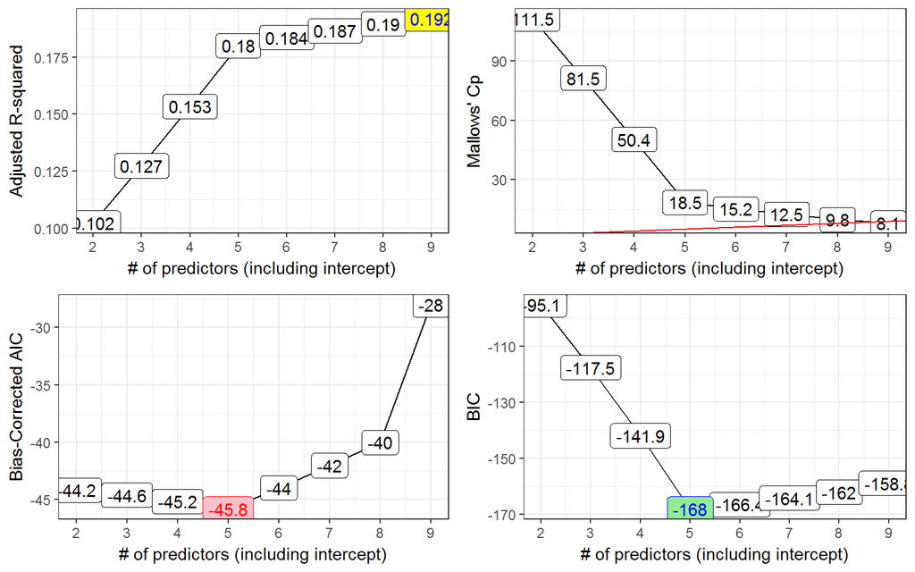

```r
p1 <- ggplot(bs_winners, aes(x = k, y = adjr2,
                       label = round(adjr2,3))) +
    geom_line() +
    geom_label() +
    geom_label(data = subset(bs_winners,
                             adjr2 == max(adjr2)),
               aes(x = k, y = adjr2, label = round(adjr2,3)),
               fill = "yellow", col = "blue") +
    theme_bw() +
    scale_x_continuous(breaks = 2:9) +
    labs(x = "# of predictors (including intercept)",
         y = "Adjusted R-squared")

p2 <- ggplot(bs_winners, aes(x = k, y = cp,
                             label = round(cp,1))) +
    geom_line() +
    geom_label() +
    geom_abline(intercept = 0, slope = 1,
                col = "red") +
    theme_bw() +
    scale_x_continuous(breaks = 2:9) +
    labs(x = "# of predictors (including intercept)",
         y = "Mallows' Cp")

p3 <- ggplot(bs_winners, aes(x = k, y = aic.c,
                             label = round(aic.c,1))) +
    geom_line() +
    geom_label() +
    geom_label(data = subset(bs_winners,
                             aic.c == min(aic.c)),
               aes(x = k, y = aic.c),
               fill = "pink", col = "red") +
    theme_bw() +
    scale_x_continuous(breaks = 2:9) +
    labs(x = "# of predictors (including intercept)",
         y = "Bias-Corrected AIC")

p4 <- ggplot(bs_winners, aes(x = k, y = bic,
                             label = round(bic,1))) +
    geom_line() +
    geom_label() +
    geom_label(data = subset(bs_winners, bic == min(bic)),
               aes(x = k, y = bic),
               fill = "lightgreen", col = "blue") +
    theme_bw() +
    scale_x_continuous(breaks = 2:9) +
    labs(x = "# of predictors (including intercept)",
         y = "BIC")

gridExtra::grid.arrange(p1, p2, p3, p4, nrow = 2)
```

### 10.4.1 Model chosen after Best Subsets analysis

```r
d <- datadist(tidy1000)
options(datadist = "d")

mod_bs <- ols(log(weight) ~ sex_f + age + health_f + rest + smoke, data = tidy1000, x = T, y = T)
mod_bs
```

```
Linear Regression Model

 ols(formula = log(weight) ~ sex_f + age + health_f + rest + smoke,
     data = tidy1000, x = T, y = T)

                Model Likelihood     Discrimination
                   Ratio Test           Indexes
 Obs    1000    LR chi2    207.86    R2       0.188
 sigma0.2155    d.f.            8    R2 adj   0.181
 d.f.    991    Pr(> chi2) 0.0000    g        0.118

 Residuals

      Min       1Q   Median       3Q      Max
 -0.66259 -0.14573 -0.01341  0.12628  0.77994


            Coef    S.E.   t      Pr(>|t|)
 Intercept   5.2770 0.0473 111.65 <0.0001
 sex_f=2    -0.1577 0.0137 -11.48 <0.0001
 age        -0.0035 0.0006  -6.04 <0.0001
 health_f=2  0.0642 0.0305   2.10 0.0357
 health_f=3  0.0965 0.0292   3.31 0.0010
 health_f=4  0.1435 0.0306   4.68 <0.0001
 health_f=5  0.2070 0.0450   4.60 <0.0001
 rest        0.0002 0.0000   5.84 <0.0001
 smoke      -0.0001 0.0000  -2.14 0.0323
```

### 10.4.2 Impact of individual predictors on the outcome

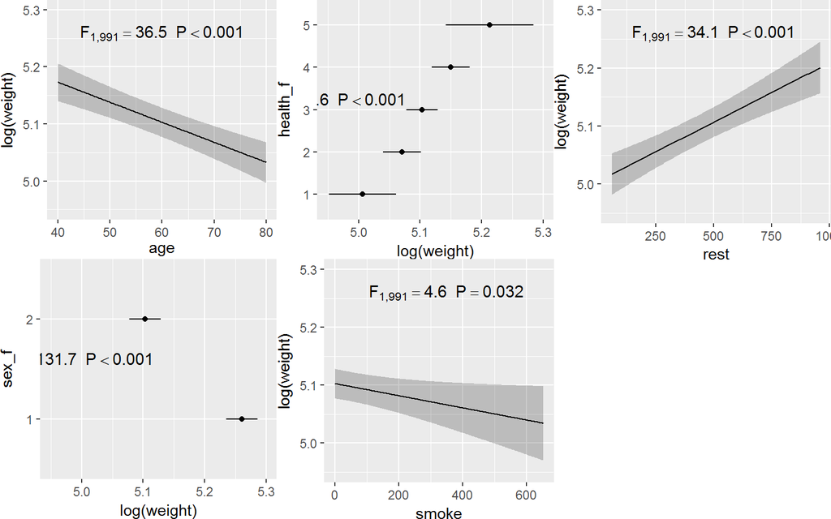

```r
ggplot(Predict(mod_bs),
anova = anova(mod_bs), pval = TRUE)
```

## 10.5 Comparing out of sample predictive ability of the model with cross validation

In order to test the validity of my model, I will use the Cross Validation method.

```r
set.seed(90210)
# Setting up the cross validation--using 10-fold validation
CV_model <- tidy1000 %>%
  crossv_kfold(k = 10) %>%
  mutate(model = map(train, ~ lm(log(weight) ~ sex_f + age + health_f + rest + smoke, data = .)))

CV_predictions <- CV_model %>%
unnest(map2(model, test, ~ augment(.x, newdata = .y)))

CV_res <- CV_predictions %>%
summarize(Model = "3",
RMSE = sqrt(mean((log(weight) - .fitted) ^2)),
MAE = mean(abs(log(weight) - .fitted)))
```

Plotting the predictions from the cross validation process.

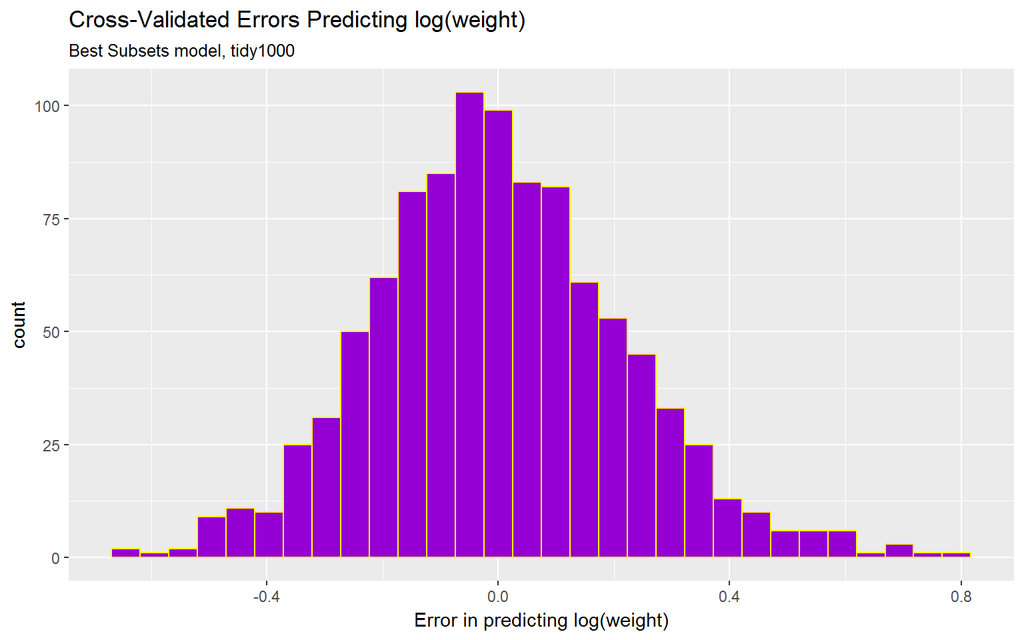

```r
CV_predictions %>%
  mutate(errors = log(weight) - .fitted) %>%
  ggplot(., aes(x = errors)) +
  geom_histogram(bins = 30, fill = "darkviolet", col = "yellow") +
  labs(title = "Cross-Validated Errors Predicting log(weight)",
       subtitle = "Best Subsets model, tidy1000", x = "Error in predicting log(weight)")
```

The model appears to be reasonable prediction-wise. There is a bit of spread in the prediction error, but very few are significantly divergent from the group. The model appears to balance predictions above and below the actual values, exhibiting a fairly normal distribution around error = 0.0.

### 10.5.1 Residual plot analyses

Next, I will examine the residual plots of the predicted values.

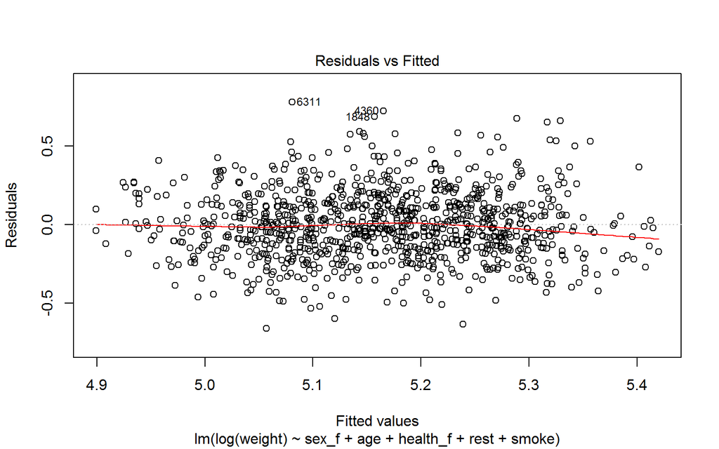

```r
mod_bs_lm <- lm(log(weight) ~ sex_f + age + health_f + rest + smoke, data = tidy1000)

plot(mod_bs_lm, which=1)
```

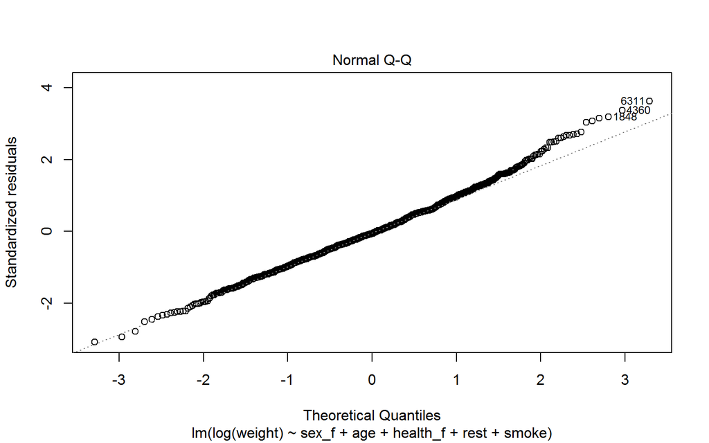

```r
plot(mod_bs_lm, which=2)
```

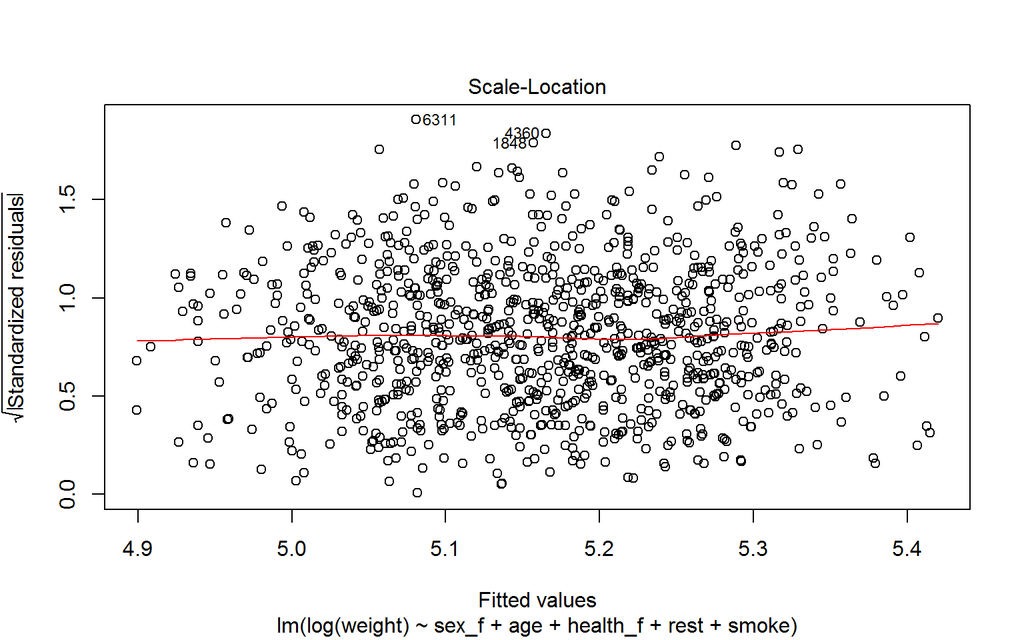

```r
plot(mod_bs_lm, which=3)
```

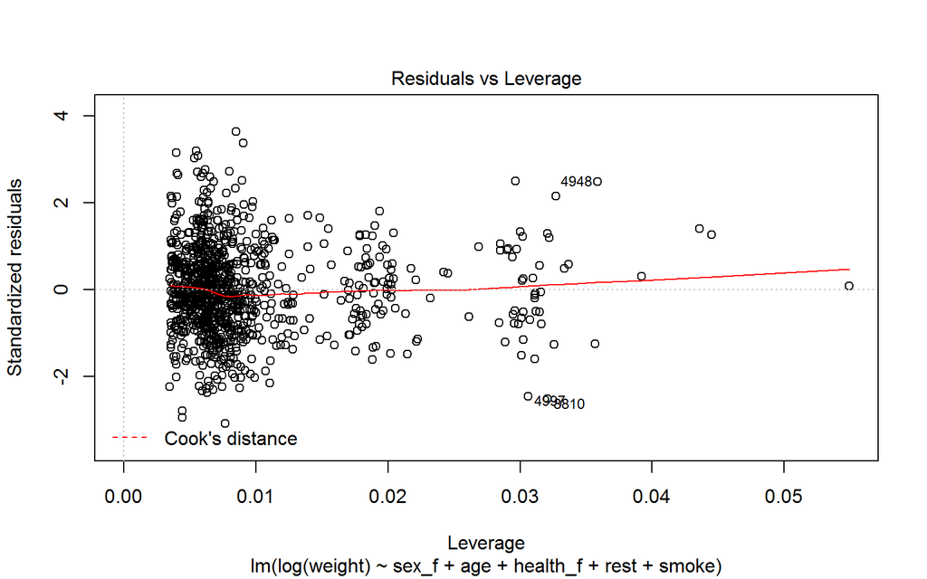

```r
plot(mod_bs_lm, which=5)
```

Based on the residuals versus fitted values plot above, there is not a curve evident in the loess smooth, but there do appear to be a few outliers that have higher residual values at the mid-upper range of the fitted values. The plot, however, does resemble a “fuzzy football.” Additionally the normal QQ plot demonstrates these outliers as well but overall there does not appear to be any major evidence of non-normality in our residuals. Further examination via Leverage plot does not reveal any points with Cook’s distance >0.5, but there are some points with a higher influence in the dataset; there are several so therefore these are likely to not be related to errors but actual observations that we need to be aware of in our model. A scale-location plot demonstrates overall constant variance across the range of fitted values of log(weight).

Therefore, the standard regression assumptions for residuals (Linearity, independence, constant variance, and normality) appear to be met. There is really little issue with normality given that the outcome was transformed to adjust for normality.

```r
summary(mod_bs_lm)
```

```
Call:
lm(formula = log(weight) ~ sex_f + age + health_f + rest + smoke,
    data = tidy1000)

Residuals:
     Min       1Q   Median       3Q      Max
-0.66259 -0.14573 -0.01341  0.12628  0.77994

Coefficients:
              Estimate Std. Error t value Pr(>|t|)
(Intercept)  5.277e+00  4.727e-02 111.647  < 2e-16 ***
sex_f2      -1.577e-01  1.374e-02 -11.477  < 2e-16 ***
age         -3.518e-03  5.824e-04  -6.040 2.18e-09 ***
health_f2    6.417e-02  3.051e-02   2.103 0.035711 *
health_f3    9.654e-02  2.916e-02   3.311 0.000965 ***
health_f4    1.435e-01  3.064e-02   4.684 3.21e-06 ***
health_f5    2.070e-01  4.498e-02   4.601 4.75e-06 ***
rest         2.043e-04  3.498e-05   5.840 7.06e-09 ***
smoke       -1.050e-04  4.896e-05  -2.144 0.032288 *
---
Signif. codes:  0 '***' 0.001 '**' 0.01 '*' 0.05 '.' 0.1 ' ' 1

Residual standard error: 0.2155 on 991 degrees of freedom
Multiple R-squared:  0.1877,    Adjusted R-squared:  0.1811
F-statistic: 28.62 on 8 and 991 DF,  p-value: < 2.2e-16
```

```r
confint(mod_bs)
```

```
                   2.5 %        97.5 %
Intercept   5.1842646374  5.369767e+00
sex_f=2    -0.1846508773 -1.307282e-01
age        -0.0046604568 -2.374793e-03
health_f=2  0.0042933719  1.240405e-01
health_f=3  0.0393159417  1.537654e-01
health_f=4  0.0833886278  2.036418e-01
health_f=5  0.1186901875  2.952206e-01
rest        0.0001356620  2.729640e-04
smoke      -0.0002010422 -8.885886e-06
```

The final model equation is:

log(weight) = 5.277 - 0.00352(age) - 0.1577(sex_female) + 0.0642(health:2) + 0.0965(health:3) + 0.1435(health:4) + 0.2070(health:5) + 0.000204(rest) - 0.000105(smoke)

The 95% confidence intervals for each coefficient are noted above and are as follows:

[output not shown]

The effect sizes plot, below, shows the change associated with moving from the 25% to 75% interval in each of the predictor’s distributions. The CI of those changes are noted by the bars surrounding the triangles, which note the effect size of that shift. Most notable in this graph is the trend for the levels of the health variable.

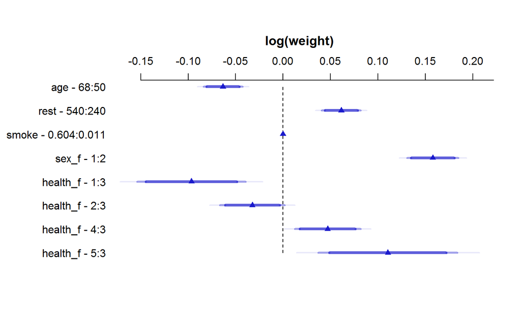

```r
plot(summary(mod_bs))
```

```r
validate(mod_bs)
```

```
          index.orig training   test optimism index.corrected  n
R-square      0.1877   0.1925 0.1803   0.0121          0.1755 40
MSE           0.0460   0.0455 0.0464  -0.0009          0.0469 40
g             0.1180   0.1189 0.1161   0.0028          0.1152 40
Intercept     0.0000   0.0000 0.1000  -0.1000          0.1000 40
Slope         1.0000   1.0000 0.9806   0.0194          0.9806 40
```

### 10.5.2 Calibt=ration of the final model

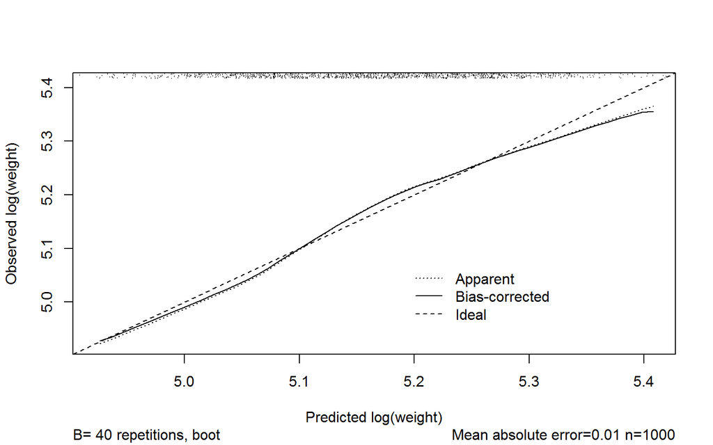

```
n=1000   Mean absolute error=0.01   Mean squared error=0.00014
0.9 Quantile of absolute error=0.016
```

```r
set.seed(90210)

plot(calibrate(mod_bs))
```

The final model selected is very well calibrated. The apparent and bias-corrected curves follow closely with the ideal curve. The main deviation occurs at the very upper end of the x-axis. This may be due to the paucity of data points at this end of the range.

### 10.5.3 Nomogram for making predictions using the final model

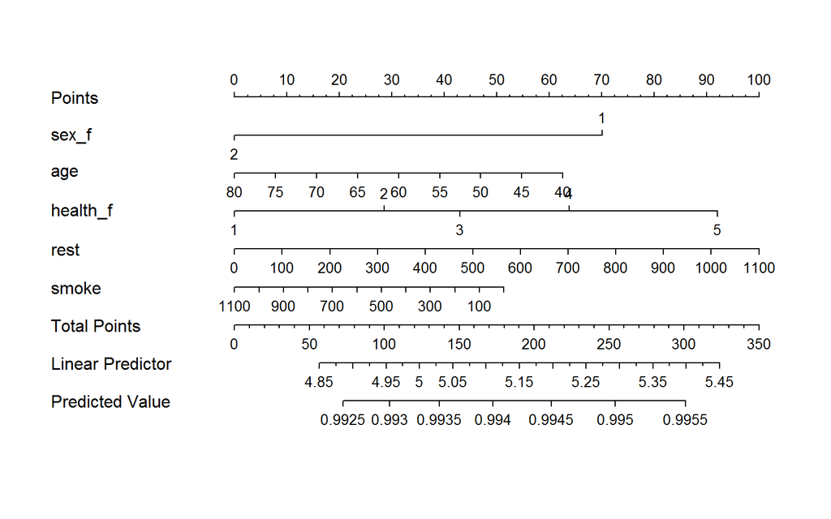

```r
plot(nomogram(mod_bs, fun = plogis))
```

# 11 Task 11 Analysis: Logistic Regression

For this logistic regression analysis, I will build a logistic model which will predict whether a person is overweight/obese, or not, from a series of predictor variables available in the NHANES database.

The first task in preparing for the logistic regression analysis is to determine the potential impact each of my potential predictors may have on my outcome of choice. To this end, I will run a Spearman Rho-squared analysis of the predictor options. I specifically included a large number of predictor options beyond the required minimum of 4. I do not expect the confounders, age and sex, to be as much of an issue in the logistic regression, due, in part, to the nature of the outcome variable. The outcome, bmi_bin was created from the BMI measurements. BMI is less variable due to age and sex, as height is part of the calculation to determine BMI. Just in case, I will graph my outcome, accounting for age and sex.

## 11.1 Initial data review

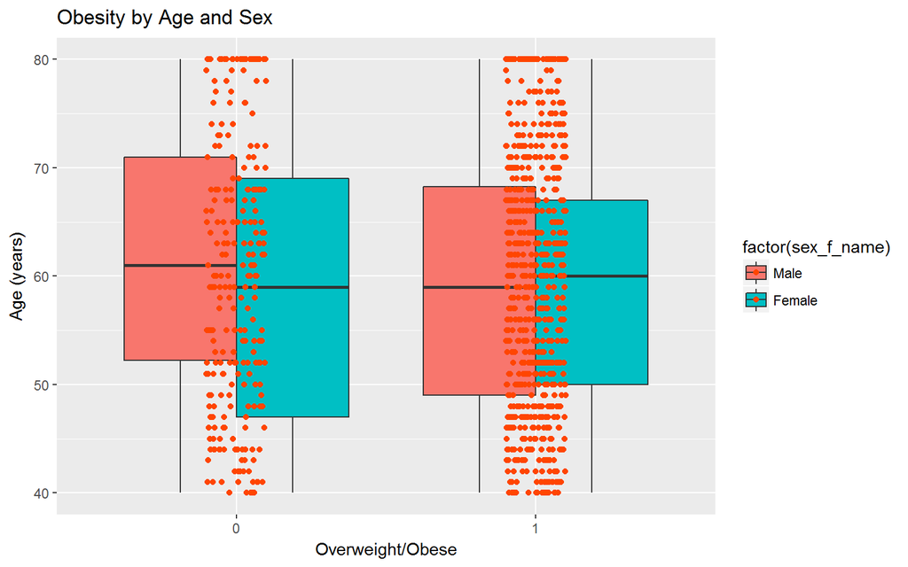

```r
ggplot(tidy1000, aes(x = factor(BMI_bin), y = age, fill=factor(sex_f_name))) +
geom_boxplot() +
  geom_jitter(width = 0.1, height = 0, color = "orangered") +
    labs(title = "Obesity by Age and Sex",
         y = "Age (years)", x = "Overweight/Obese")
```

As expected, there is essentially no difference in out outcome due to either age of sex. It is noted, however, that there appears to be a much larger population classified as overweight/obese (BMI_bin = 1) compared to under/normal weight (BMI_bin = 0). I will also take a look at the dataset through a skim.

```r
tidy1000 %>% select(-SEQN) %>% skim()
```

```
Skim summary statistics
 n obs: 1000
 n variables: 18

Variable type: factor
   variable missing complete    n n_unique
      BMI_f       0     1000 1000        2
     food_f       0     1000 1000        3
   health_f       0     1000 1000        5
     oral_f       0     1000 1000        6
      sex_f       0     1000 1000        2
 sex_f_name       0     1000 1000        2
    smell_f       0     1000 1000        4
    taste_f       0     1000 1000        3
                              top_counts ordered
                             b. : 741, a   FALSE
                             a. : 794, b   FALSE
 3: 421, 2: 243, 4: 236, 1: 63             FALSE
 1: 456, 2: 160, 6: 155, 3: 99             FALSE
         2: 514, 1: 486, NA: 0             FALSE
     Fem: 514, Mal: 486, NA: 0             FALSE
                             a. : 589, b   FALSE
                             a. : 688, b   FALSE

Variable type: integer
 variable missing complete    n   mean     sd p0 p25 median p75 p100
      age       0     1000 1000  59.56  11.88 40  50     60  68   80
     food       0     1000 1000   8.24   1.55  3   9      9   9    9
     rest       0     1000 1000 420.47 195.46  1 240    480 540 1080
    sleep       0     1000 1000   6.87   1.49  0   6      7   8   12
   weight       0     1000 1000 179.97  44.95 81 150    174 204  400
     hist
 ▇▇▇▇▇▆▅▇
 ▁▁▁▁▁▁▁▇
 ▂▅▅▇▃▂▁▁
 ▁▁▁▇▆▇▁▁
 ▁▆▇▃▁▁▁▁

Variable type: numeric
 variable missing complete    n  mean     sd   p0    p25 median   p75
      bmi       0     1000 1000 29.51   7    14.2 24.8   28.2   32.52
  BMI_bin       0     1000 1000  0.74   0.44  0    0      1      1
    smell       0     1000 1000  6.4    1.77  0    6      7      8
    smoke       0     1000 1000 59.46 141.77  0    0.011  0.024  0.6
    taste       0     1000 1000  1.57   0.7   0    1      2      2
   p100     hist
   77.5 ▂▇▅▁▁▁▁▁
    1   ▃▁▁▁▁▁▁▇
    8   ▁▁▁▂▂▆▇▇
 1030   ▇▁▁▁▁▁▁▁
    2   ▂▁▁▂▁▁▁▇
```

Before deciding which predictors to use in my initial model, I want to look at the Spearman Rho-squared plot. This plot should give me an idea of the predictive power of each potential predictor.

#### 11.1.0.1 Spearman Rho-squared Plot

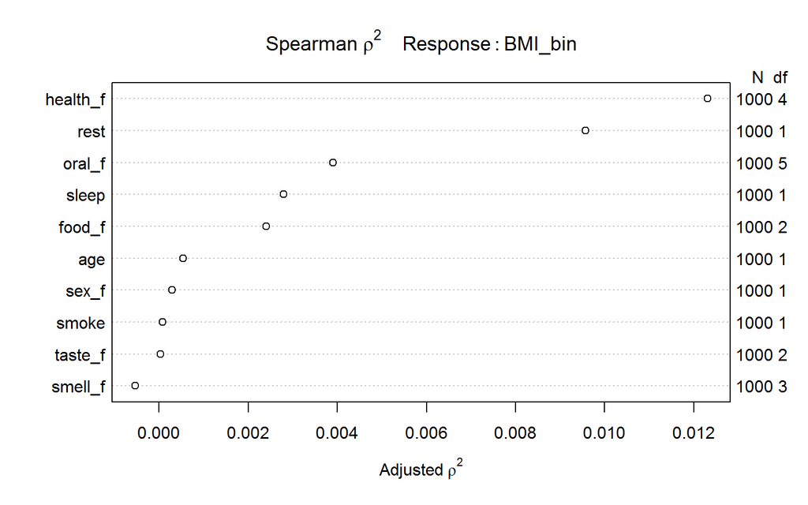

```r
plot(Hmisc::spearman2(BMI_bin ~ age + sex_f + health_f + oral_f + smoke + sleep + rest + taste_f + smell_f + food_f, data=tidy1000))
```

The Spearman Rho-squared plot indicates that the variables which may pack the greatest predictive punch are health and rest first, followed by oral, sleep, and food. The remaining variables may have an impact, however they are likely to make much less of a difference in the predictive power of the model. To assess non-linearity of predictors, I will focus on the two apparently most important predictors, health and rest. Health is a factor, and rest is a quantitative variable. I will include an interaction between these predictirs and a spline for rest in my initial model.

## 11.2 Building initial logistic models and non-linearity assessments

```r
log_ks_nonlin <- lrm(BMI_bin ~ age + sex_f + health_f * rcs(rest, 3) + oral_f + smoke + sleep + taste_f + smell_f + food_f, data = tidy1000, x = TRUE, y = TRUE)

log_ks_nonlin
```

```
Logistic Regression Model

 lrm(formula = BMI_bin ~ age + sex_f + health_f * rcs(rest, 3) +
     oral_f + smoke + sleep + taste_f + smell_f + food_f, data = tidy1000,
     x = TRUE, y = TRUE)

                       Model Likelihood     Discrimination    Rank Discrim.
                          Ratio Test           Indexes           Indexes
 Obs          1000    LR chi2      71.81    R2       0.102    C       0.670
  0            259    d.f.            30    g        0.827    Dxy     0.340
  1            741    Pr(> chi2) <0.0001    gr       2.287    gamma   0.342
 max |deriv| 3e-05                          gp       0.127    tau-a   0.131
                                            Brier    0.179

                       Coef    S.E.   Wald Z Pr(>|Z|)
 Intercept              0.8154 1.2290  0.66  0.5070
 age                   -0.0067 0.0069 -0.97  0.3335
 sex_f=2               -0.2056 0.1559 -1.32  0.1872
 health_f=2             0.7600 1.0667  0.71  0.4761
 health_f=3             0.8433 1.0302  0.82  0.4131
 health_f=4             0.7280 1.0825  0.67  0.5012
 health_f=5             5.6381 3.8476  1.47  0.1428
 rest                   0.0016 0.0030  0.53  0.5953
 rest'                 -0.0005 0.0028 -0.17  0.8626
 oral_f=2               0.2724 0.2288  1.19  0.2339
 oral_f=3               0.3498 0.2762  1.27  0.2053
 oral_f=4               0.7749 0.3635  2.13  0.0330
 oral_f=5               0.0577 0.3375  0.17  0.8642
 oral_f=6              -0.0663 0.2287 -0.29  0.7719
 smoke                 -0.0019 0.0005 -3.73  0.0002
 sleep                 -0.0738 0.0536 -1.38  0.1686
 taste_f=b. Borderline  0.4498 0.3015  1.49  0.1357
 taste_f=a. Normal      0.1855 0.2575  0.72  0.4713
 smell_f=c. Moderate   -0.3631 0.4613 -0.79  0.4312
 smell_f=b. Mild       -0.3977 0.4167 -0.95  0.3399
 smell_f=a. Normal     -0.1054 0.4165 -0.25  0.8002
 food_f=b. Moderate     0.1745 0.4243  0.41  0.6809
 food_f=a. Mild/none   -0.2164 0.3903 -0.55  0.5793
 health_f=2 * rest     -0.0005 0.0034 -0.14  0.8918
 health_f=3 * rest      0.0004 0.0033  0.13  0.8968
 health_f=4 * rest      0.0006 0.0035  0.16  0.8753
 health_f=5 * rest     -0.0180 0.0133 -1.35  0.1757
 health_f=2 * rest'     0.0010 0.0033  0.30  0.7645
 health_f=3 * rest'    -0.0010 0.0030 -0.33  0.7444
 health_f=4 * rest'     0.0015 0.0036  0.40  0.6860
 health_f=5 * rest'     0.0359 0.0247  1.45  0.1457
```

```r
anova(log_ks_nonlin)
```

```
                Wald Statistics          Response: BMI_bin

 Factor                                         Chi-Square d.f. P
 age                                             0.94       1   0.3335
 sex_f                                           1.74       1   0.1872
 health_f  (Factor+Higher Order Factors)        18.12      12   0.1121
  All Interactions                               6.52       8   0.5895
 rest  (Factor+Higher Order Factors)            17.75      10   0.0593
  All Interactions                               6.52       8   0.5895
  Nonlinear (Factor+Higher Order Factors)        3.84       5   0.5725
 oral_f                                          7.28       5   0.2009
 smoke                                          13.94       1   0.0002
 sleep                                           1.90       1   0.1686
 taste_f                                         2.57       2   0.2773
 smell_f                                         3.46       3   0.3258
 food_f                                          2.77       2   0.2499
 health_f * rest  (Factor+Higher Order Factors)  6.52       8   0.5895
  Nonlinear                                      3.52       4   0.4746
  Nonlinear Interaction : f(A,B) vs. AB          3.52       4   0.4746
 TOTAL NONLINEAR                                 3.84       5   0.5725
 TOTAL NONLINEAR + INTERACTION                   7.43       9   0.5925
 TOTAL                                          58.84      30   0.0013
```

I will build a second model without the non-linear terms:

```r
log_ks <- lrm(BMI_bin ~ age + sex_f + health_f + rest + oral_f + smoke + sleep + taste_f + smell_f + food_f, data = tidy1000, x = TRUE, y = TRUE)

log_ks
```

```
Logistic Regression Model

 lrm(formula = BMI_bin ~ age + sex_f + health_f + rest + oral_f +
     smoke + sleep + taste_f + smell_f + food_f, data = tidy1000,
     x = TRUE, y = TRUE)

                       Model Likelihood     Discrimination    Rank Discrim.
                          Ratio Test           Indexes           Indexes
 Obs          1000    LR chi2      61.22    R2       0.087    C       0.663
  0            259    d.f.            21    g        0.659    Dxy     0.327
  1            741    Pr(> chi2) <0.0001    gr       1.932    gamma   0.329
 max |deriv| 6e-06                          gp       0.120    tau-a   0.126
                                            Brier    0.180

                       Coef    S.E.   Wald Z Pr(>|Z|)
 Intercept              0.6630 0.8431  0.79  0.4317
 age                   -0.0062 0.0069 -0.90  0.3655
 sex_f=2               -0.2163 0.1546 -1.40  0.1620
 health_f=2             0.7008 0.3007  2.33  0.0198
 health_f=3             0.8848 0.2910  3.04  0.0024
 health_f=4             1.0785 0.3192  3.38  0.0007
 health_f=5             1.2476 0.5252  2.38  0.0175
 rest                   0.0014 0.0004  3.53  0.0004
 oral_f=2               0.2936 0.2271  1.29  0.1960
 oral_f=3               0.3769 0.2736  1.38  0.1684
 oral_f=4               0.8026 0.3607  2.23  0.0261
 oral_f=5               0.0314 0.3342  0.09  0.9251
 oral_f=6              -0.0690 0.2271 -0.30  0.7614
 smoke                 -0.0018 0.0005 -3.64  0.0003
 sleep                 -0.0737 0.0526 -1.40  0.1608
 taste_f=b. Borderline  0.4633 0.2988  1.55  0.1210
 taste_f=a. Normal      0.2226 0.2539  0.88  0.3808
 smell_f=c. Moderate   -0.3654 0.4517 -0.81  0.4185
 smell_f=b. Mild       -0.3974 0.4088 -0.97  0.3310
 smell_f=a. Normal     -0.1101 0.4088 -0.27  0.7877
 food_f=b. Moderate     0.2728 0.4154  0.66  0.5113
 food_f=a. Mild/none   -0.1126 0.3821 -0.29  0.7682
```

With this second model, log_ks, which does not contain non-linear elements, the predictors which show some significance are: health, rest, smoke, and one level of oral. These predictors have low p-values and high Wald Statistics (chi-square). This coincides well with the Spearman Rho-squared plot’s assessments.

I want to use another method for determining the best subset of predictors for my final model. I will try the method of ridge regression with lasso.

## 11.3 Ridge Regression with Lasso

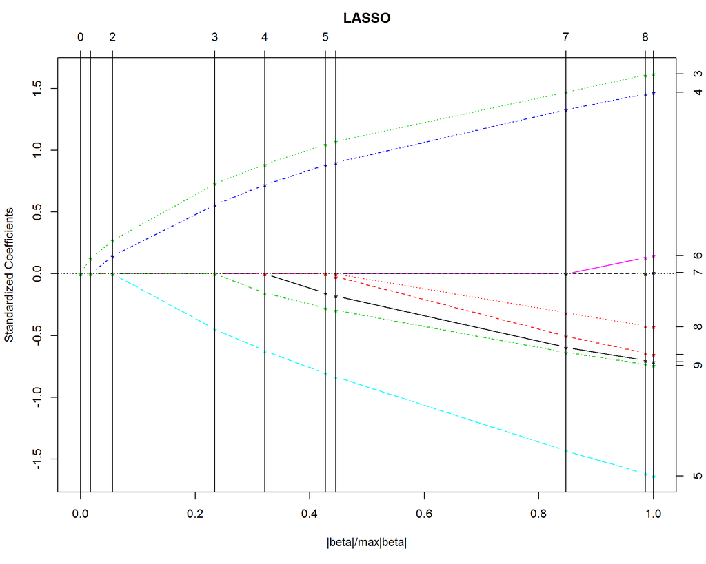

```r
#change fig.height to 50 to separate out variable numbers
lasso1 <- lars(preds, tidy1000$BMI_bin, type="lasso")

plot(lasso1)
```

```r
summary(lasso1)
```

```
LARS/LASSO
Call: lars(x = preds, y = tidy1000$BMI_bin, type = "lasso")
  Df    Rss      Cp
0  1 191.92 37.1686
1  2 191.54 37.1492
2  3 190.77 34.9554
3  4 187.93 21.6239
4  5 186.90 18.0956
5  6 185.89 14.6591
6  7 185.74 15.8321
7  8 183.70  6.8229
8  9 183.55  8.0065
9 10 183.54 10.0000
```

```r
set.seed(90210)
lassocv <- cv.lars(preds, tidy1000$BMI_bin, K=10)
```

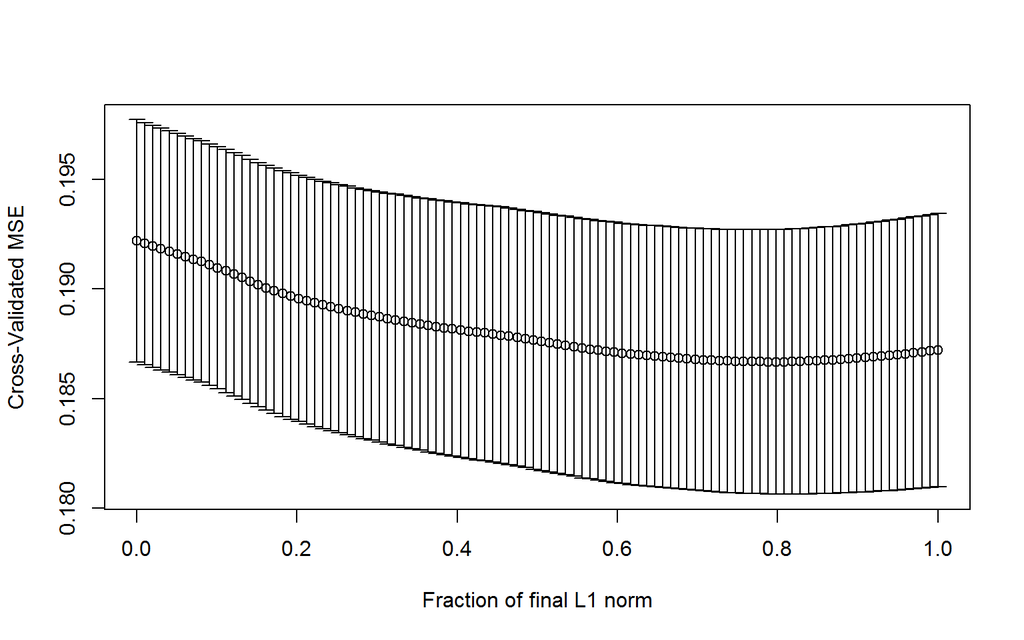

What value of the key fraction minimizes cross-validated MSE?

```r
frac <- lassocv$index[which.min(lassocv$cv)]
frac
```

```
[1] 0.7979798
```

```r
coef.cv <- coef(lasso1, s=frac, mode="fraction")
round(coef.cv,4)
```

```
     age    sex_f health_f     rest    smoke  taste_f   oral_f   food_f
 -0.0014  -0.0281   0.0481   0.0002  -0.0003   0.0000   0.0000  -0.0164
   sleep
 -0.0126
```

I find it rather curious that the lasso procedure dropped the oral predictor, as it was one of the strongest in the Spearmen Rho-squared plot. It also dropped taste, but taste and smell exhibit a high degree of collinearity, so I am not too disturbed by that loss. I will create the lrm and glm models now, so I may assess them.

```r
# create lrm model
lasso_lrm <- lrm(BMI_bin ~ sex_f + age + health_f + rest + smell_f + sleep + food_f + smoke, data = tidy1000, x = TRUE, y = TRUE)
# create glm model
lasso_glm <- glm(BMI_bin ~ sex_f + age + health_f + rest + smell_f + sleep + food_f + smoke, data = tidy1000, family = binomial)
```

With the models created, I will initially assess them first by simply running the model and using lrm’s tools.

```r
lasso_lrm
```

```
Logistic Regression Model

 lrm(formula = BMI_bin ~ sex_f + age + health_f + rest + smell_f +
     sleep + food_f + smoke, data = tidy1000, x = TRUE, y = TRUE)

                       Model Likelihood     Discrimination    Rank Discrim.
                          Ratio Test           Indexes           Indexes
 Obs          1000    LR chi2      49.87    R2       0.071    C       0.646
  0            259    d.f.            14    g        0.574    Dxy     0.292
  1            741    Pr(> chi2) <0.0001    gr       1.776    gamma   0.294
 max |deriv| 1e-07                          gp       0.107    tau-a   0.112
                                            Brier    0.182

                     Coef    S.E.   Wald Z Pr(>|Z|)
 Intercept            1.0132 0.8152  1.24  0.2139
 sex_f=2             -0.2309 0.1514 -1.53  0.1272
 age                 -0.0079 0.0068 -1.17  0.2437
 health_f=2           0.6748 0.2985  2.26  0.0238
 health_f=3           0.8876 0.2870  3.09  0.0020
 health_f=4           1.0789 0.3118  3.46  0.0005
 health_f=5           1.3077 0.5146  2.54  0.0110
 rest                 0.0014 0.0004  3.43  0.0006
 smell_f=c. Moderate -0.2683 0.4419 -0.61  0.5438
 smell_f=b. Mild     -0.2203 0.3836 -0.57  0.5659
 smell_f=a. Normal    0.0255 0.3784  0.07  0.9462
 sleep               -0.0782 0.0517 -1.51  0.1300
 food_f=b. Moderate   0.3128 0.4118  0.76  0.4474
 food_f=a. Mild/none -0.0835 0.3754 -0.22  0.8240
 smoke               -0.0018 0.0005 -3.62  0.0003
```

From this model summary, this does not look like a very strong model. The model’s likelihood ratio indicates that at least some of these predictors are helpful. The C-statistic (which is what is generated with a ROC curve) is 0.646, which means that the predictive ability of the model is not much greater than predicting by chance alone. The Nagelkerke R^2 of 0.071 tells us that the fitted model could benefit from a great deal of improvement, as it is very far from a value of 1. The predictors smell and food do not retain significance in this model, as the Wald Z statistic and associated p=values are large. Predictors with borderline significance are sex and sleep. Overall, this is not looking like a strong model.

#### 11.3.0.1 ANOVA evaluations of glm and lrm models

```r
anova(lasso_lrm)
```

```
                Wald Statistics          Response: BMI_bin

 Factor     Chi-Square d.f. P
 sex_f       2.33       1   0.1272
 age         1.36       1   0.2437
 health_f   14.28       4   0.0064
 rest       11.76       1   0.0006
 smell_f     2.64       3   0.4510
 sleep       2.29       1   0.1300
 food_f      2.96       2   0.2278
 smoke      13.11       1   0.0003
 TOTAL      46.72      14   <.0001
```

From this ANOVA’s Wald statistics, the predictors with the greatest impact on the model are health, rest, and smoke, with each demonstrating high Chi-squared and low p-values.

```r
anova(lasso_glm)
```

```
Analysis of Deviance Table

Model: binomial, link: logit

Response: BMI_bin

Terms added sequentially (first to last)

         Df Deviance Resid. Df Resid. Dev
NULL                       999     1144.0
sex_f     1   1.2948       998     1142.7
age       1   2.1015       997     1140.6
health_f  4  15.3506       993     1125.3
rest      1  11.1148       992     1114.2
smell_f   3   2.7980       989     1111.4
sleep     1   2.3374       988     1109.0
food_f    2   2.1067       986     1106.9
smoke     1  12.7657       985     1094.2
```

The ANOVA of the glm model helps us understand the impact of each predictor in terms of loss of df and decrease in deviance.This analysis indicates that health, rest, and smoke have the biggest impact on the decrease in deviabce of the residuals. Even with the entire model in place, we use only 14 degrees of freedom, leaving us with 985 remaining. Since our sample size is so large. we are not limited in our analysis by degrees of freedom.

#### 11.3.0.2 Summary analysis of glm model

```r
summary(lasso_glm)
```

```
Call:
glm(formula = BMI_bin ~ sex_f + age + health_f + rest + smell_f +
    sleep + food_f + smoke, family = binomial, data = tidy1000)

Deviance Residuals:
    Min       1Q   Median       3Q      Max
-2.1803  -1.1302   0.6655   0.7877   1.5954

Coefficients:
                     Estimate Std. Error z value Pr(>|z|)
(Intercept)         1.0132326  0.8151751   1.243 0.213881
sex_f2             -0.2309148  0.1513788  -1.525 0.127157
age                -0.0078976  0.0067739  -1.166 0.243662
health_f2           0.6748208  0.2985054   2.261 0.023780 *
health_f3           0.8876344  0.2870175   3.093 0.001984 **
health_f4           1.0788659  0.3117801   3.460 0.000539 ***
health_f5           1.3076818  0.5145826   2.541 0.011046 *
rest                0.0013697  0.0003994   3.429 0.000605 ***
smell_fc. Moderate -0.2682524  0.4418525  -0.607 0.543779
smell_fb. Mild     -0.2202508  0.3836232  -0.574 0.565878
smell_fa. Normal    0.0255345  0.3784316   0.067 0.946204
sleep              -0.0782494  0.0516806  -1.514 0.130002
food_fb. Moderate   0.3128010  0.4117564   0.760 0.447449
food_fa. Mild/none -0.0834740  0.3754216  -0.222 0.824043
smoke              -0.0018034  0.0004980  -3.621 0.000293 ***
---
Signif. codes:  0 '***' 0.001 '**' 0.01 '*' 0.05 '.' 0.1 ' ' 1

(Dispersion parameter for binomial family taken to be 1)

    Null deviance: 1144.0  on 999  degrees of freedom
Residual deviance: 1094.1  on 985  degrees of freedom
AIC: 1124.1

Number of Fisher Scoring iterations: 4
```

The summary of the glm model confirms what the lrm model information told told us, that the most important predictors are health, rest, and smoke.

Next, I want to examine the effect sizes for the predictors–using the lrm model.

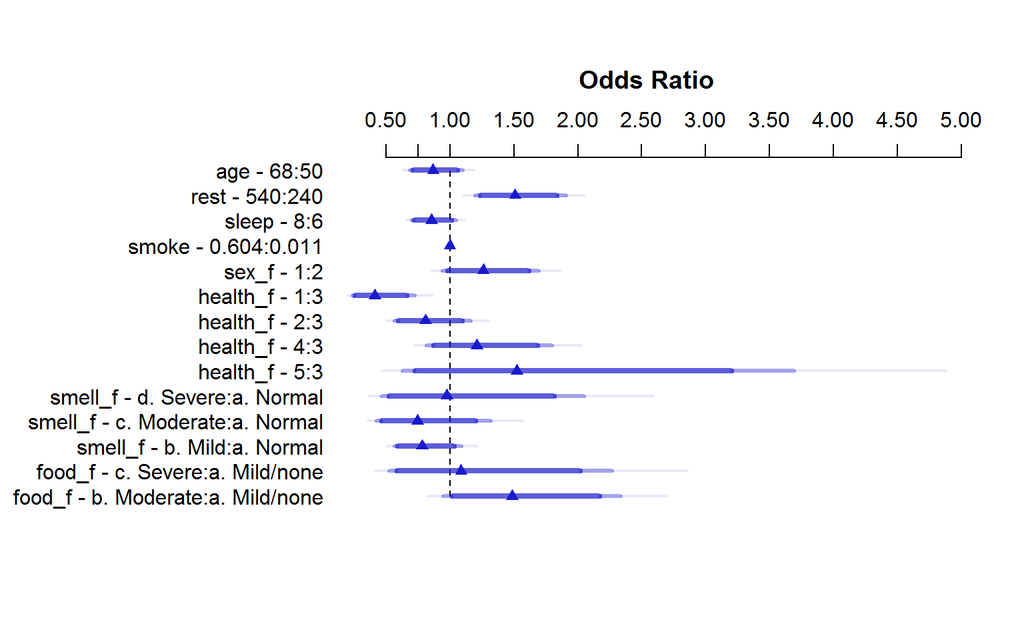

```r
plot(summary(lasso_lrm))
```

The effect sizes as shown in the plot above help us understand the significance differences across the predictors.

- Age, sex, and sleep: For age, sex, and sleep, which are not significant contributors, they have a very narrow effect size which crosses an odds ratio of 1.0–which means no difference in odds.
- Rest: The predictor rest, however, also has a small effect size, but it does not cross odds = 1.0, and therefore the predictor shows some significance in terms of predictive ability.
- Smoke: The predictor smoke is significant, and the effect size is incredibly tiny–and right by odds = 1.0. For smoke, the 25-75% range is from 0.011 to 0.604. Perhaps the significance is related to the tiny effect size???
- Health: This predictor is a multi-leveled factor. Each level has a different effect size and range at different odds ratios. There is an apparent trend that the lower scores have a lower odds ratio than the higher ones. This trend is likely responsible for the significance observed with this predictor.
- Smell and Food: The predictors smell and food are leveled factors. Each level has a fairly large effect size, each of which cross the odds = 1.0 threshold, thus accounting for the lack of significance observed.

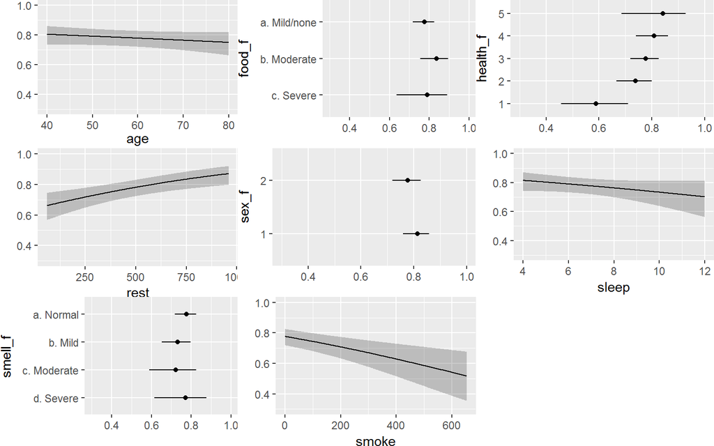

```r
ggplot(Predict(lasso_lrm, fun = plogis))
```

The individual predictor plots also help explain the effect of each predictor on the model.

- Age: As age increases, the odds of being overweight/obese decrease, but not a great deal.
- Food: The odds ranges across the factor levels overlap almost completely and without a directional trend across levels, explaining the lack of significance.
- Health: The odds ranges across the levels of this factor overlap a bit, but the trend is directional, which may contribute to the signifance observed.
- Rest: As the amount of time a person is at rest increases, so do the odds of being overweight/obese. The slope of this trend line is reasonably steep and the confidence intervals are fairly tight.
- Sex: The odds ranges for male and female overlap a great deal, explaining the lack of significance.
- Sleep: As the amount of sleep an individual typically gets increases, the odds of being overweight/obese decreases slightly. The CIs also spread a bit at the upper and lower ranges. The slope is fairly flat, possibly explaining the lack of significance.
- Smell: The odds ranges for all of the levels of this factor overlap, explaining the lack of significance for this factor in the model.
- Smoke: As the cotinine levels increase in individuals, indicating a current smoker with increasingly heavy useage, the odds of being overweight/obese decreases. The slope of the line is fairly steep, but the CIs fan out at the upper end of the smoke level–possibly die to lower numbers of people in this range. The fairly steep slope may explain the significance of this predictor.

#### 11.3.0.3 Calibration of model

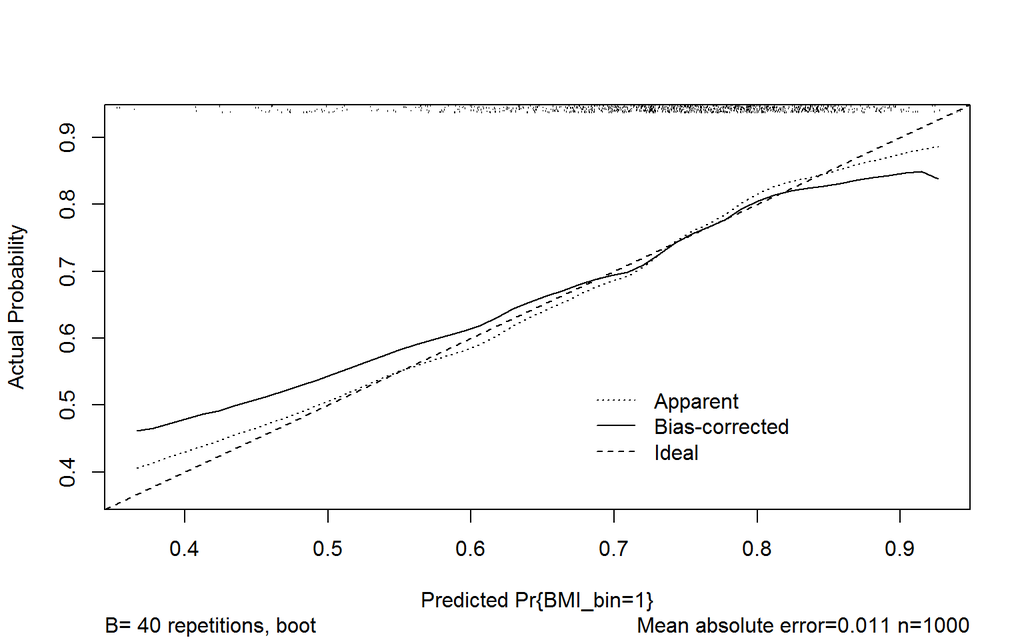

```
n=1000   Mean absolute error=0.011   Mean squared error=0.00033
0.9 Quantile of absolute error=0.031
```

```r
plot(calibrate(lasso_lrm))
```

```r
set.seed(90210)
validate(lasso_lrm, B = 100)
```

```
          index.orig training   test optimism index.corrected   n
Dxy           0.2918   0.3232 0.2553   0.0679          0.2240 100
R2            0.0714   0.0916 0.0562   0.0355          0.0359 100
Intercept     0.0000   0.0000 0.2191  -0.2191          0.2191 100
Slope         1.0000   1.0000 0.7752   0.2248          0.7752 100
Emax          0.0000   0.0000 0.0983   0.0983          0.0983 100
D             0.0489   0.0635 0.0380   0.0255          0.0234 100
U            -0.0020  -0.0020 0.0031  -0.0051          0.0031 100
Q             0.0509   0.0655 0.0349   0.0306          0.0203 100
B             0.1820   0.1783 0.1849  -0.0065          0.1885 100
g             0.5744   0.6666 0.5086   0.1580          0.4163 100
gp            0.1070   0.1206 0.0949   0.0257          0.0812 100
```

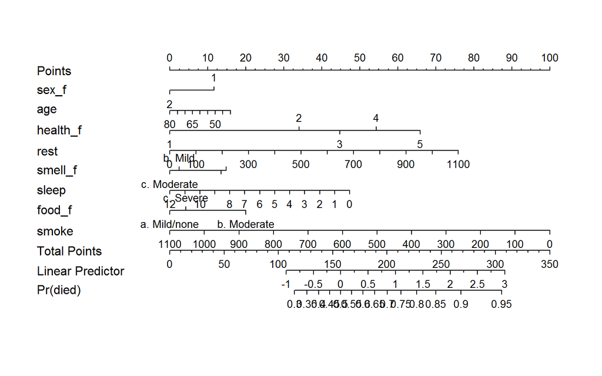

```r
plot(nomogram(lasso_lrm, fun=plogis,
funlabel="Pr(died)"))
```

#### 11.3.0.4 plotting model predictions using full dataset as new data

```r
d <- datadist(nhanes_tidy)
options(datadist = "d")

pred_data <- glm(BMI_bin ~ sex_f + age + health_f + rest + smell_f + sleep + food_f + smoke,
data = nhanes_tidy, x = TRUE, y = TRUE)
pred_data
```

```
Call:  glm(formula = BMI_bin ~ sex_f + age + health_f + rest + smell_f +
    sleep + food_f + smoke, data = nhanes_tidy, x = TRUE, y = TRUE)

Coefficients:
       (Intercept)              sex_f2                 age
         0.6035050          -0.0557556          -0.0008356
         health_f2           health_f3           health_f4
         0.1398004           0.2020302           0.2490285
         health_f5                rest  smell_fc. Moderate
         0.2769298           0.0001172          -0.0210304
    smell_fb. Mild    smell_fa. Normal               sleep
        -0.0005049           0.0349450          -0.0052159
 food_fb. Moderate  food_fa. Mild/none               smoke
         0.0641169           0.0076757          -0.0003557

Degrees of Freedom: 3240 Total (i.e. Null);  3226 Residual
Null Deviance:      626.6
Residual Deviance: 600.7    AIC: 3767
```

```r
pred_data_aug <- augment(pred_data, nhanes_tidy,
                     type.predict = "response")
head(pred_data_aug)
```

```
  .rownames  SEQN weight  bmi BMI_bin                 BMI_f age sex_f
1         1 73557    180 26.7       1   b. Overweight/Obese  69     1
2         2 73558    200 28.6       1   b. Overweight/Obese  54     1
3         3 73559    195 28.9       1   b. Overweight/Obese  72     1
4         5 73561    120 19.7       0 a. Normal/Underweight  73     2
5         6 73562    235 41.7       1   b. Overweight/Obese  56     1
6         7 73564    212 35.7       1   b. Overweight/Obese  61     2
  sex_f_name health_f oral_f smoke sleep rest taste     taste_f smell
1       Male        2      6 6.510     7  600     2   a. Normal     4
2       Male        4      6 4.070     9  540     2   a. Normal     8
3       Male        3      1 0.052     8  300     2   a. Normal     7
4     Female        5      1 0.011     9  480     0 c. Impaired     6
5       Male        5      5 0.011     5  360     2   a. Normal     8
6     Female        3      1 0.015     9   60     2   a. Normal     8
      smell_f food       food_f   .fitted    .se.fit     .resid
1 c. Moderate    9 a. Mild/none 0.7038022 0.03363466  0.2961978
2   a. Normal    9 a. Mild/none 0.8649423 0.02497941  0.1350577
3   a. Normal    9 a. Mild/none 0.7814146 0.02019427  0.2185854
4     b. Mild    9 a. Mild/none 0.7801721 0.04116839 -0.7801721
5   a. Normal    9 a. Mild/none 0.8923793 0.04031674  0.1076207
6   a. Normal    9 a. Mild/none 0.7015142 0.02438832  0.2984858
         .hat    .sigma      .cooksd .std.resid
1 0.006075642 0.4315452 1.931861e-04  0.6885162
2 0.003351062 0.4315704 2.203250e-05  0.3135144
3 0.002190152 0.4315598 3.763119e-05  0.5071149
4 0.009102191 0.4313562 2.020207e-03 -1.8162895
5 0.008729490 0.4315728 3.684028e-05  0.2505006
6 0.003194345 0.4315448 1.025499e-04  0.6928314
```

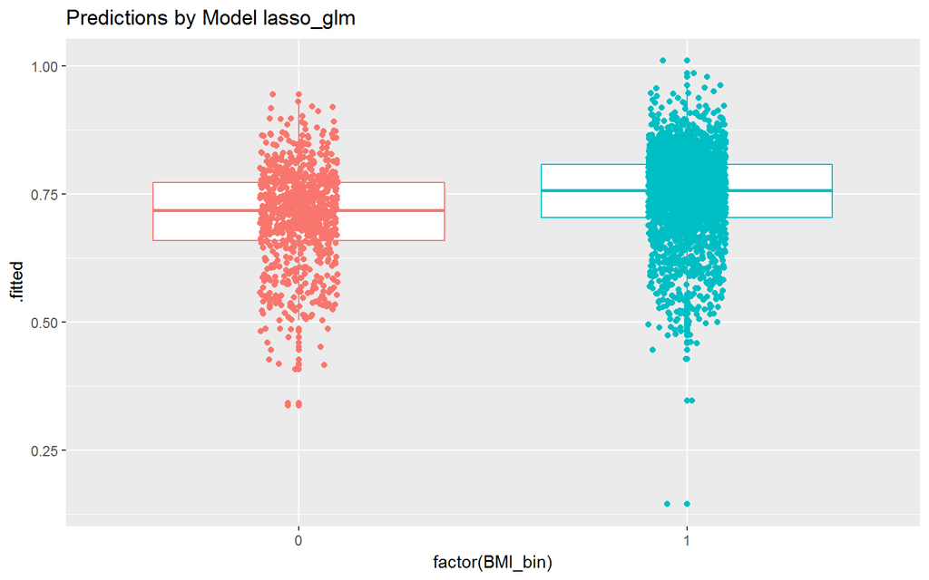

```r
ggplot(pred_data_aug, aes(x = factor(BMI_bin), y = .fitted, col = factor(BMI_bin))) +
    geom_boxplot() +
    geom_jitter(width = 0.1) +
    guides(col = FALSE) +
  labs(title="Predictions by Model lasso_glm")
```

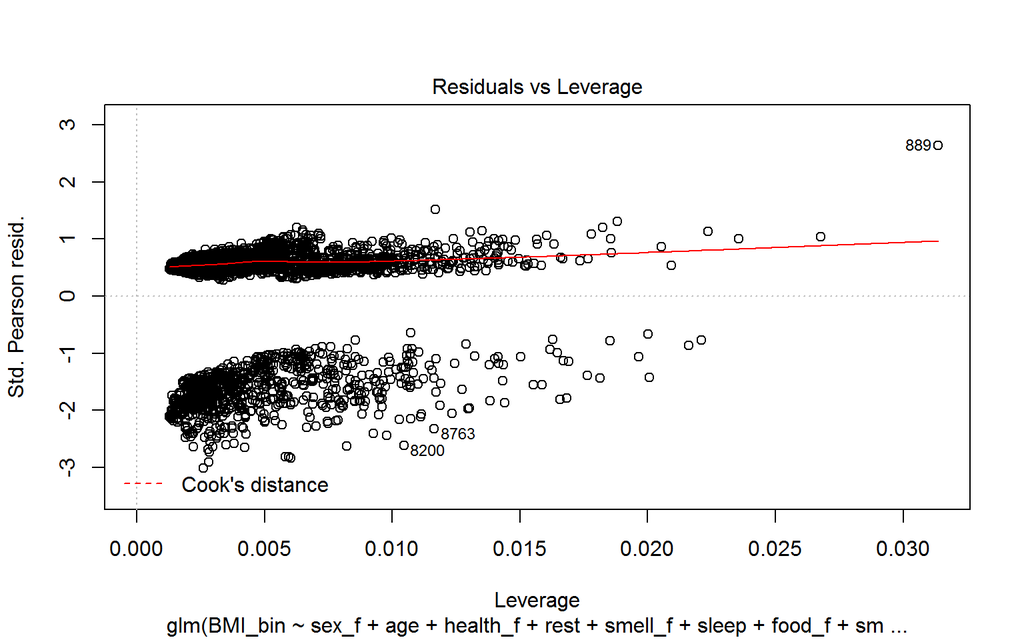

```r
infl_plots <- glm(BMI_bin ~ sex_f + age + health_f + rest + smell_f + sleep + food_f + smoke, data = nhanes_tidy, family = binomial)
par(mfrow=c(1,1))
plot(infl_plots, which=5)
```